# Module 1 Final Project

Student name: **Cynthia Pedrasa**  
Student pace: **self paced**  
Scheduled project review date/time: **Tue, Mar 26, 2019 3:30pm - 4:15pm (EDT)**  
Instructor name: **Eli Thomas**  
Blog post URL: https://cpedrasa.github.io/exploratory_data_analysis

Introduction: Data Science Framework

I. Obtaining the Data

- A. Import the Libraries
- B. Read the csv file
- C. Inspect the Data Types
- D. Inspect the unique column values
- E. Review of Data Types

II. Scrubbing the Data

- A. Removing non-predictor columns
- B. Inspect the missing values
- C. Fill in the missing values
- D. Converting Non-numeric Data Types
- E. Converting Numerical data types to Categorical

III. Exploring the Data

- A. Descriptive Statistics
- B. Outliers Check
- C. Linearity check
- D. Normality check
- E. Multicollinearity check

IV. Modeling the Data

- A. Preprocess the Dummy Variables
- B. Feature Scaling & Normalization
- C. Run the Linear Model
- D. Model Fit with most appropriate variables
- E. Train Test Split
- F. Cross Validation
- G. Feature ranking

V. iNterpreting the Data

# Introduction

Using the OSEMN framework the project will go through the Data Science phases to get, clean, explore, model and interpret this dataset using the multivariate linear regression to predict the sale price of houses as accurately as possible.

## Data Science Workflow

Understanding the typical work flow on how the data science process works is a crucial step towards business understanding and problem solving. Using the OSEMN Framework the student will go through the different steps of the framework in an iterative and non-linear process. The table of contents section just serves to organize the information in this project and the iterative process will be evident as the student reflect back the new information e.g. discovered from the exploration back to processing the data to gain the insight necessary to interpret the results of the model and communicate results to stakeholders.

- **O.** Obtain the data
- **S.** Scrubbing/ cleaning the Data
- **E.** Exploring/ Visualizing the Data
- **M.** Modeling the data
- **N.** iNterpret the Data

Before we begin the OSEMN Pipeline the most crucial step is to understand the problem we are trying to solve. In this Module 1 Project, the student will be working with the home sales data from King County, WA. The **primary objective** is to predict home sales price by building a multivariate linear regression model that will make accurate quantitative predictions of data.

**Multivariate linear regression model** is used when we want to predict the value of a variable based on the value of two or more other variables. The variable we want to predict is called the dependent variable (or sometimes, the outcome, target or criterion variable). In this project, we would like to determine which features best predict the price of a home.

In this project we would like to find the answers to the following questions:

- Which features have the biggest impact on home sale prices?
- What is the Median Home Sale Price by Zip Code?
- Where are the Top 20 Most Expensive Homes Sold located?
- Do more bedrooms add value?
- Do more bathrooms add value?
- How does the condition affect the price of a home?
- How does the grade (quality of construction and design) affect home pricing?
- Which number of floors add the most value to the sale of a home?
- What is the home construction history like at King County
- What is the best month and day to sell a home?
- What is the distribution of homes sold with views, waterfronts, or have undergone renovation?
- Which features add the most value to home sales?

## I. Obtaining the Data

### 1a. Import the Libraries

```python
#We begin by importing the libraries needed for reading the file and processing the dataset
import pandas as pd
import numpy as np

#Import the libraries needed for visualization
import matplotlib.pyplot as plt
%matplotlib inline
import seaborn as sns
#plt.style.use('ggplot')


#Import the libraries needed for Linear Regression validation and cross validation using sci-kit learn
from sklearn.linear_model import LinearRegression   # calculating OLS
from sklearn.preprocessing import StandardScaler
from sklearn.model_selection import train_test_split, cross_val_score  #for train-test split
from sklearn import metrics   #for calculating MSE & cross validation
from sklearn.metrics import mean_squared_error  #calculate MSE
from sklearn.model_selection import cross_val_score  # Cross validation
from sklearn.feature_selection import RFE
linreg = LinearRegression()




# Statsmodels libraries to run Ordinary Least Squares regression on  our data.
import statsmodels.api as sm
from statsmodels.api import formula
from statsmodels.formula.api import ols
import statsmodels.stats as stats
import statsmodels.formula.api as smf


#import statsmodels.formula.api as smf
from statsmodels.graphics.gofplots import qqplot
plt.style.use('seaborn')

import scipy.stats as stats
from scipy.stats import kurtosis, skew
from IPython.display import HTML

#control display of warnings in the output;
import warnings
warnings.filterwarnings('ignore')

# display 2 decimal points for the output formatting of floats
#pd.set_option('display.float_format', lambda x: '%.2f' % x)
```

[Jump back to Table of Contents]

### 1b. Read the csv file

```python
# We then proceed with reading the King County House Sales comma-separated values(csv) data file into DataFrame
df = pd.read_csv('kc_house_data.csv')
```

[**`pandas.read_table`**](http://pandas.pydata.org/pandas-docs/stable/generated/pandas.read_table.html)

```python
# Next we we will examine the first 5 rows and the column labels of the house sales dataframe
display(df.head()  , "The full column names are as follows:" ,df.columns)
```

|  | id | date | price | bedrooms | bathrooms | sqft_living | sqft_lot | floors | waterfront | view | ... | grade | sqft_above | sqft_basement | yr_built | yr_renovated | zipcode | lat | long | sqft_living15 | sqft_lot15 |
| --- | --- | --- | --- | --- | --- | --- | --- | --- | --- | --- | --- | --- | --- | --- | --- | --- | --- | --- | --- | --- | --- |
| 0 | 7129300520 | 10/13/2014 | 221900.0 | 3 | 1.00 | 1180 | 5650 | 1.0 | NaN | 0.0 | ... | 7 | 1180 | 0.0 | 1955 | 0.0 | 98178 | 47.5112 | -122.257 | 1340 | 5650 |
| 1 | 6414100192 | 12/9/2014 | 538000.0 | 3 | 2.25 | 2570 | 7242 | 2.0 | 0.0 | 0.0 | ... | 7 | 2170 | 400.0 | 1951 | 1991.0 | 98125 | 47.7210 | -122.319 | 1690 | 7639 |
| 2 | 5631500400 | 2/25/2015 | 180000.0 | 2 | 1.00 | 770 | 10000 | 1.0 | 0.0 | 0.0 | ... | 6 | 770 | 0.0 | 1933 | NaN | 98028 | 47.7379 | -122.233 | 2720 | 8062 |
| 3 | 2487200875 | 12/9/2014 | 604000.0 | 4 | 3.00 | 1960 | 5000 | 1.0 | 0.0 | 0.0 | ... | 7 | 1050 | 910.0 | 1965 | 0.0 | 98136 | 47.5208 | -122.393 | 1360 | 5000 |
| 4 | 1954400510 | 2/18/2015 | 510000.0 | 3 | 2.00 | 1680 | 8080 | 1.0 | 0.0 | 0.0 | ... | 8 | 1680 | 0.0 | 1987 | 0.0 | 98074 | 47.6168 | -122.045 | 1800 | 7503 |

5 rows × 21 columns

```
'The full column names are as follows:'
```

```
Index(['id', 'date', 'price', 'bedrooms', 'bathrooms', 'sqft_living',
       'sqft_lot', 'floors', 'waterfront', 'view', 'condition', 'grade',
       'sqft_above', 'sqft_basement', 'yr_built', 'yr_renovated', 'zipcode',
       'lat', 'long', 'sqft_living15', 'sqft_lot15'],
      dtype='object')
```

[**`pandas.DataFrame.head`**](http://pandas.pydata.org/pandas-docs/stable/reference/api/pandas.DataFrame.head.html?highlight=head)

A preliminary inspection of the data shows that there are **21 columns** or variables.

[Jump back to Table of Contents]

### 1c. Inspect the Data Types

```python
#What are the variables and their datatypes on the dataset?
df.info()
```

```
<class 'pandas.core.frame.DataFrame'>
RangeIndex: 21597 entries, 0 to 21596
Data columns (total 21 columns):
id               21597 non-null int64
date             21597 non-null object
price            21597 non-null float64
bedrooms         21597 non-null int64
bathrooms        21597 non-null float64
sqft_living      21597 non-null int64
sqft_lot         21597 non-null int64
floors           21597 non-null float64
waterfront       19221 non-null float64
view             21534 non-null float64
condition        21597 non-null int64
grade            21597 non-null int64
sqft_above       21597 non-null int64
sqft_basement    21597 non-null object
yr_built         21597 non-null int64
yr_renovated     17755 non-null float64
zipcode          21597 non-null int64
lat              21597 non-null float64
long             21597 non-null float64
sqft_living15    21597 non-null int64
sqft_lot15       21597 non-null int64
dtypes: float64(8), int64(11), object(2)
memory usage: 3.5+ MB
```

[**`pandas.DataFrame.info`**](http://pandas.pydata.org/pandas-docs/stable/reference/api/pandas.DataFrame.info.html)

[Jump back to Table of Contents]

### 1d. Inspect the unique column values

```python
#Count the distinct observations (less than 30) for each of the columns excluding NaN
#to facilitate our review of the appropriateness of the feature's datatypes
print('\n','Column unique values','\n','==================================')
for col in df:
    if  df[col].nunique() < 50:
        print(col, '=', df[col].nunique(), 'unique values = ', df[col].unique().tolist())
    else:
        print( col, '=', df[col].nunique())
```

```
 Column unique values
 ==================================
id = 21420
date = 372
price = 3622
bedrooms = 12 unique values =  [3, 2, 4, 5, 1, 6, 7, 8, 9, 11, 10, 33]
bathrooms = 29 unique values =  [1.0, 2.25, 3.0, 2.0, 4.5, 1.5, 2.5, 1.75, 2.75, 3.25, 4.0, 3.5, 0.75, 4.75, 5.0, 4.25, 3.75, 1.25, 5.25, 6.0, 0.5, 5.5, 6.75, 5.75, 8.0, 7.5, 7.75, 6.25, 6.5]
sqft_living = 1034
sqft_lot = 9776
floors = 6 unique values =  [1.0, 2.0, 1.5, 3.0, 2.5, 3.5]
waterfront = 2 unique values =  [nan, 0.0, 1.0]
view = 5 unique values =  [0.0, nan, 3.0, 4.0, 2.0, 1.0]
condition = 5 unique values =  [3, 5, 4, 1, 2]
grade = 11 unique values =  [7, 6, 8, 11, 9, 5, 10, 12, 4, 3, 13]
sqft_above = 942
sqft_basement = 304
yr_built = 116
yr_renovated = 70
zipcode = 70
lat = 5033
long = 751
sqft_living15 = 777
sqft_lot15 = 8682
```

[**`pandas.DataFrame.unique`**](http://pandas.pydata.org/pandas-docs/stable/generated/pandas.Series.unique.html) and [**`pandas.DataFrame.nunique`**](http://pandas.pydata.org/pandas-docs/stable/generated/pandas.Series.nunique.html)

[Jump back to Table of Contents]

### 1e. Review of Data Types

The total number of observations(rows) = 21597

Here are a few other observations that we need to take into consideration in the next phase of scrubbing the data.

- There are also missing data points in the **view** column (nan) in addition to the **waterfront and yr_renovated** columns.
- Two non-numeric (**object**) variables were found. These will need to be converted to numeric.
  - **date** (object) - Date house was sold
  - **sqft_basement** (object) - square footage of the basement
- There are several variables with numeric datatypes that should be converted as **categorical** variables.  
  Column descriptions reference from [Kaggle](https://www.kaggle.com/harlfoxem/housesalesprediction)
  - **floors** (float) - Total floors (levels) in house
  - **waterfront** (float) - House which has a view to a waterfront
  - **view** (float) - Has been viewed? An index from 0 to 4 of how good the view of the property was
  - **condition** (int) - How good the condition is ( Overall )? An index from 1 to 5 on the condition of the home
  - **zipcode** (int) - zipcode area the house is located
  - **grade** (int) - overall grade given to the housing unit, based on King County grading system? An index from 1 to 13
    - 1-4 falls short of building construction and design
    - 5-6 unsatisfactory building construction and design
    - 7-8 has an average level of construction and design
    - 9-10 has above average of building construction and design
    - 11-13 have a high quality level of construction and design Value Definition 0 Unknown 1 Cabin 2 Substandard 3 Poor 4 Low 5 Fair 6 Low Average 7 Average 8 Good 9 Better 10 Very Good 11 Excellent 12 Luxury 13 Mansion 20 Exceptional Properties
- There are two datepart numeric variables that should be converted as **categorical** variables.
  - **yr_built** (int) - The year the house was initially built
  - **yr_renovated**(float) - The year when house was renovated
- The following variables are **continuous** variables.
  - **price** (float64) - Price of each home sold - **the prediction target**
  - **bedrooms** (int64) - Number of Bedrooms
  - **bathrooms** (float64) - Number of bathrooms, where .5 accounts for a room with a toilet but no shower
  - **sqft_living** (int64)- square footage of the home
  - **sqft_lot** (int64) - square footage of the lot/land space
  - **sqft_above** (int64) - square footage of house apart from basement
  - **sqft_living15** (int64) - The square footage of interior housing living space for the nearest 15 neighbors
  - **sqft_lot15** (int64) - The square footage of the land lots of the nearest 15 neighbors
  - **lat** (float64) - Latitude coordinate
  - **long** (float64) - Longitude coordinate

[Jump back to Table of Contents]

## 2. Scrubbing the Data

### 2a. Removing non-predictor columns

```python
#Remove the unique id column since it is a not a predictor then inspect the head
df = df[df.columns.difference(['id'])]
df.head()
```

|  | bathrooms | bedrooms | condition | date | floors | grade | lat | long | price | sqft_above | sqft_basement | sqft_living | sqft_living15 | sqft_lot | sqft_lot15 | view | waterfront | yr_built | yr_renovated | zipcode |
| --- | --- | --- | --- | --- | --- | --- | --- | --- | --- | --- | --- | --- | --- | --- | --- | --- | --- | --- | --- | --- |
| 0 | 1.00 | 3 | 3 | 10/13/2014 | 1.0 | 7 | 47.5112 | -122.257 | 221900.0 | 1180 | 0.0 | 1180 | 1340 | 5650 | 5650 | 0.0 | NaN | 1955 | 0.0 | 98178 |
| 1 | 2.25 | 3 | 3 | 12/9/2014 | 2.0 | 7 | 47.7210 | -122.319 | 538000.0 | 2170 | 400.0 | 2570 | 1690 | 7242 | 7639 | 0.0 | 0.0 | 1951 | 1991.0 | 98125 |
| 2 | 1.00 | 2 | 3 | 2/25/2015 | 1.0 | 6 | 47.7379 | -122.233 | 180000.0 | 770 | 0.0 | 770 | 2720 | 10000 | 8062 | 0.0 | 0.0 | 1933 | NaN | 98028 |
| 3 | 3.00 | 4 | 5 | 12/9/2014 | 1.0 | 7 | 47.5208 | -122.393 | 604000.0 | 1050 | 910.0 | 1960 | 1360 | 5000 | 5000 | 0.0 | 0.0 | 1965 | 0.0 | 98136 |
| 4 | 2.00 | 3 | 3 | 2/18/2015 | 1.0 | 8 | 47.6168 | -122.045 | 510000.0 | 1680 | 0.0 | 1680 | 1800 | 8080 | 7503 | 0.0 | 0.0 | 1987 | 0.0 | 98074 |

### 2b. Inspect the missing values

```python
#Find the columns with missing data points (NaN) values
display(df.isna().sum())
```

```
bathrooms           0
bedrooms            0
condition           0
date                0
floors              0
grade               0
lat                 0
long                0
price               0
sqft_above          0
sqft_basement       0
sqft_living         0
sqft_living15       0
sqft_lot            0
sqft_lot15          0
view               63
waterfront       2376
yr_built            0
yr_renovated     3842
zipcode             0
dtype: int64
```

[**`pandas.DataFrame.isnull`**](http://pandas.pydata.org/pandas-docs/stable/generated/pandas.DataFrame.isnull.html)

```python
#We have missing values for waterfront, view, and yr_renovated. Let's check the % of the missing data points
for col in df:
    if df[col].isnull().sum() != 0:
        print(col ,'has', df[col].isnull().sum(),'missing values','(',round(df[col].isnull().sum() * 100 / len(df[col]),2),'%)')
print("Total number of missing data values =", df.isnull().sum().sum())
```

```
view has 63 missing values ( 0.29 %)
waterfront has 2376 missing values ( 11.0 %)
yr_renovated has 3842 missing values ( 17.79 %)
Total number of missing data values = 6281
```

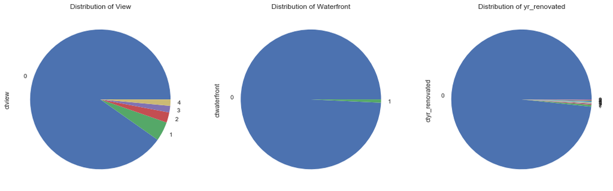

```
0.0    19422
2.0      957
3.0      508
1.0      330
4.0      317
Name: view, dtype: int64
```

```
0.0    19075
1.0      146
Name: waterfront, dtype: int64
```

```
0.0       17011
2014.0       73
2003.0       31
2013.0       31
2007.0       30
2000.0       29
2005.0       29
1990.0       22
2004.0       22
2009.0       21
Name: yr_renovated, dtype: int64
```

```python
#Inspect the view, waterfront and yr_renovated columns' value counts
from pandasql import sqldf
pysqldf = lambda q: sqldf(q, globals())
q1 = """SELECT  view, count(view) as ctview FROM df GROUP BY view ORDER BY 2 desc;"""
q2 = """SELECT  waterfront, count(waterfront) as ctwaterfront FROM df GROUP BY waterfront ORDER BY 2 desc;"""
q3 = """SELECT  yr_renovated, count(yr_renovated) as ctyr_renovated FROM df GROUP BY yr_renovated  ORDER BY 2 desc LIMIT 10;"""

dview = pysqldf(q1)
dwaterfront = pysqldf(q2)
dyr_renovated = pysqldf(q3)

#Create and label the pie charts for each feature below!
fig, axes = plt.subplots(nrows=1, ncols=3, figsize=(18,8))

dview['ctview'].plot(kind='pie', ax=axes[0])
axes[0].set_title('Distribution of View')

dwaterfront['ctwaterfront'].plot(kind='pie', ax=axes[1])
axes[1].set_title('Distribution of Waterfront')

dyr_renovated['ctyr_renovated'].plot(kind='pie', ax=axes[2])
axes[2].set_title('Distribution of yr_renovated')
plt.show()
display(df.view.value_counts(),  df.waterfront.value_counts(), df.yr_renovated.value_counts().nlargest(10))
```

The missing values detected by pandas using the isnull() method are the view, waterfront and yr_renovated features. In the first phase, we have inspected certain column's unique values.

- We know that **view** has 5 total unique values excluding NaN = [0.0, 3.0, 4.0, 2.0, 1.0].  
  Since the missing values are insignificant at only 0.29% , we can safely replace the NaNs with 0, which is the most frequently occurring value for houses (19422 no views).
- **Waterfront** has 2376 or 11% missing values and has 2 unique values= [0.0, 1.0]
- **yr_renovated** has 3,842 or 17.79% missing data points and has 70 unique values.

However, when running the unique values count, we are also able to discover the **"non-standard" missing values** as shown in the yr_renovated value counts where there are 17,011 observations with the year '0.0'.  
Missing values can be treated as a separate category by itself. We can create another category for the missing values for the **yr_renovated** feature.

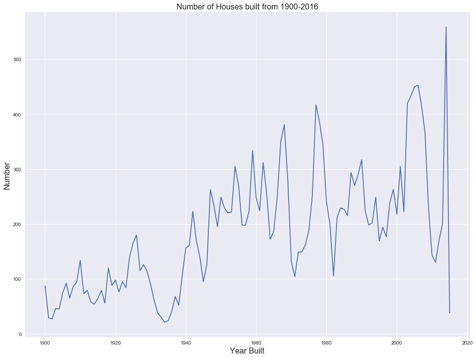

```python
#Let's see the trend of housing build in King's County over the years
plt.figure(figsize=(16,12))
plt.plot(df.groupby('yr_built').agg({'yr_built': 'count'}))
plt.title('Number of Houses built from 1900-2016', fontsize =16)
plt.xlabel('Year Built', fontsize=16)
plt.ylabel('Number', fontsize=16)
plt.show()
```

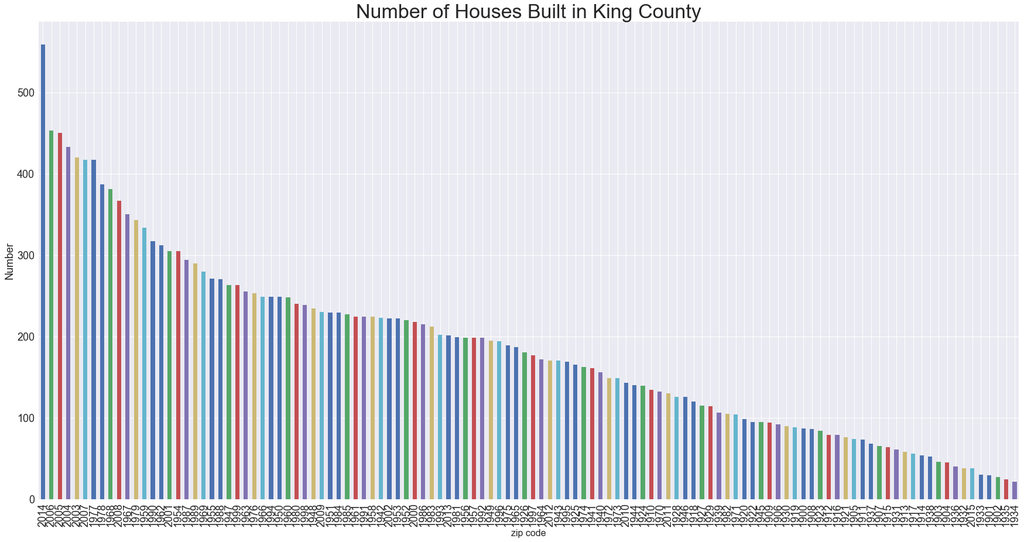

```python
#There is an increasing trend in housing constructions in King County.
#We would like to know in which years where most houses were built in Kings County
plt.figure(figsize=(30,15))
df['yr_built'].value_counts().plot(kind='bar', fontsize=18)
plt.xlabel('zip code', fontsize = 16)
plt.ylabel('Number', fontsize = 18)
plt.title('Number of Houses Built in King County', fontsize=34)
plt.show()
```

The top 10 years were most homes were built are in the years 2014,2006,2005,2004,2003,2007,1977,1978, 1968 and 2008. The years where contructions were the lowest are 1934, 1935, 1902,1901,1933, 2015,1932,1936,1904, and 1903

[**`pandas.DataFrame.value_counts`**](http://pandas.pydata.org/pandas-docs/stable/generated/pandas.Series.value_counts.html)

[Jump back to Table of Contents]

### 2c. Fill in the missing values

```python
# Since most waterfront is zero, fill in the waterfront missing values with 0, since houses are either with waterfront (1)or without (0).
df.loc[df.waterfront.isna(), 'waterfront'] = 0
df.waterfront = df.waterfront.astype('int')

# We have 5 unique values for view and we would like to use the median, for filing in the missing values.
#In this case, the median is 0, which is also the mode for this column
df['view'].fillna(df['view'].median(), inplace=True )
df.view = df.view.astype('int')

# We will replace the NaN with 'missing' and the 0 value in the yr_renovated features
df.loc[df.yr_renovated.isna(), 'yr_renovated'] = 0

# Let's confirm that the missing values were filled in (verify increase in 0.0 totals)
display(df['view'].value_counts(), df['waterfront'].value_counts(), df['yr_renovated'].value_counts().nlargest(5))
```

```
0    19485
2      957
3      508
1      330
4      317
Name: view, dtype: int64
```

```
0    21451
1      146
Name: waterfront, dtype: int64
```

```
0.0       20853
2014.0       73
2003.0       31
2013.0       31
2007.0       30
Name: yr_renovated, dtype: int64
```

[**`pandas.DataFrame.fillna`**](http://pandas.pydata.org/pandas-docs/stable/generated/pandas.DataFrame.fillna.html)

```python
#Verify if there are any missing values left
df.isna().sum().tolist()
```

```
[0, 0, 0, 0, 0, 0, 0, 0, 0, 0, 0, 0, 0, 0, 0, 0, 0, 0, 0, 0]
```

[**`pandas.Series.tolist`**](https://pandas.pydata.org/pandas-docs/stable/reference/api/pandas.Series.tolist.html)

### 2d. Converting Non-numeric Data Types

```python
#Great! Now that we have dealt with all the missing data, we will convert the columns to their appropriate
#datatypes as previously noted.
#There are non-numeric (object) variables that need to be converted to numeric.
# Create the date column data type with datetime type.
date = pd.to_datetime(df['date'])

#sqft_basement - this is a continuous variable that should have a float data type. Error was received when converting.
#Let's first reveal the non-numeric values in sqft_basement so we convert from object to numeric type
df[pd.to_numeric(df['sqft_basement'], errors='coerce').isnull()].head()
```

|  | bathrooms | bedrooms | condition | date | floors | grade | lat | long | price | sqft_above | sqft_basement | sqft_living | sqft_living15 | sqft_lot | sqft_lot15 | view | waterfront | yr_built | yr_renovated | zipcode |
| --- | --- | --- | --- | --- | --- | --- | --- | --- | --- | --- | --- | --- | --- | --- | --- | --- | --- | --- | --- | --- |
| 6 | 2.25 | 3 | 3 | 6/27/2014 | 2.0 | 7 | 47.3097 | -122.327 | 257500.0 | 1715 | ? | 1715 | 2238 | 6819 | 6819 | 0 | 0 | 1995 | 0.0 | 98003 |
| 18 | 1.00 | 2 | 4 | 12/5/2014 | 1.0 | 7 | 47.3089 | -122.210 | 189000.0 | 1200 | ? | 1200 | 1060 | 9850 | 5095 | 0 | 0 | 1921 | 0.0 | 98002 |
| 42 | 2.75 | 5 | 3 | 7/7/2014 | 2.0 | 9 | 47.6848 | -122.016 | 861990.0 | 3595 | ? | 3595 | 3625 | 5639 | 5639 | 0 | 0 | 2014 | 0.0 | 98053 |
| 79 | 2.50 | 4 | 3 | 3/23/2015 | 2.0 | 10 | 47.3420 | -122.025 | 720000.0 | 3450 | ? | 3450 | 3350 | 39683 | 39750 | 0 | 0 | 2002 | 0.0 | 98010 |
| 112 | 1.75 | 3 | 4 | 9/16/2014 | 1.0 | 7 | 47.3624 | -122.031 | 272500.0 | 1160 | ? | 1540 | 1540 | 12600 | 11656 | 0 | 0 | 1980 | 0.0 | 98038 |

```python
#The head shows the non-numeric '?'s in the sqft_basement column that need to be replaced. Let's count the ? values.
df['sqft_basement'].value_counts().nlargest(10)
```

```
0.0       12826
?           454
600.0       217
500.0       209
700.0       208
800.0       201
400.0       184
1000.0      148
300.0       142
900.0       142
Name: sqft_basement, dtype: int64
```

```python
#There are 454 non-numeric '?'s found in the sqft_basement column
#Let's replace all "?" with the value 0.0 and convert it to numeric data type
df['sqft_basement'] = df.sqft_basement.replace('?',0.0).astype(float)
df['sqft_basement'].value_counts().nlargest(10)
```

```
0.0       13280
600.0       217
500.0       209
700.0       208
800.0       201
400.0       184
1000.0      148
900.0       142
300.0       142
200.0       105
Name: sqft_basement, dtype: int64
```

[**`pandas.Series.str.replace`**](http://pandas.pydata.org/pandas-docs/stable/generated/pandas.Series.str.replace.html)

```python
#most houses do not have basements. Let's see the percentage
print('Homes with 0 basements', round( sum(df.sqft_basement == 0.0) / len(df), 2 ) * 100, '%' )
```

```
Homes with 0 basements 61.0 %
```

Since there is a huge percentage of houses without basement (61%), like the waterfall feature, this should be categorical with values (0, 1)

```python
#Let's re-check to see any remaining null values
df.isna().sum()
```

```
bathrooms        0
bedrooms         0
condition        0
date             0
floors           0
grade            0
lat              0
long             0
price            0
sqft_above       0
sqft_basement    0
sqft_living      0
sqft_living15    0
sqft_lot         0
sqft_lot15       0
view             0
waterfront       0
yr_built         0
yr_renovated     0
zipcode          0
dtype: int64
```

We have completed searching and dealing with the missing values. All of the features now have 21597 observations each.

[Jump back to Table of Contents]

## 3. Exploring the Data

### 3a. Descriptive Statistics

```python
# Below we generated the descriptive statistics to summarize the central tendency (mean, median, mode),
# dispersion and shape of the dataset’s distribution, excluding NaN values.
# We have round up the values to two decimal places for easy viewing of the 5 point statistics.
display(np.round(df.describe() ,2))

#Look at the range of the values
objectcol = ['price','sqft_above','sqft_living','sqft_living15','sqft_basement','sqft_lot','sqft_lot15']
print('      Range','\n','================')
for col in objectcol:
    print(col, " = " ,int(df[col].max())- int(df[col].min()))
```

|  | bathrooms | bedrooms | condition | floors | grade | lat | long | price | sqft_above | sqft_basement | sqft_living | sqft_living15 | sqft_lot | sqft_lot15 | view | waterfront | yr_built | yr_renovated | zipcode |
| --- | --- | --- | --- | --- | --- | --- | --- | --- | --- | --- | --- | --- | --- | --- | --- | --- | --- | --- | --- |
| count | 21597.00 | 21597.00 | 21597.00 | 21597.00 | 21597.00 | 21597.00 | 21597.00 | 21597.00 | 21597.00 | 21597.00 | 21597.00 | 21597.00 | 21597.00 | 21597.00 | 21597.00 | 21597.00 | 21597.00 | 21597.00 | 21597.00 |
| mean | 2.12 | 3.37 | 3.41 | 1.49 | 7.66 | 47.56 | -122.21 | 540296.57 | 1788.60 | 285.72 | 2080.32 | 1986.62 | 15099.41 | 12758.28 | 0.23 | 0.01 | 1971.00 | 68.76 | 98077.95 |
| std | 0.77 | 0.93 | 0.65 | 0.54 | 1.17 | 0.14 | 0.14 | 367368.14 | 827.76 | 439.82 | 918.11 | 685.23 | 41412.64 | 27274.44 | 0.76 | 0.08 | 29.38 | 364.04 | 53.51 |
| min | 0.50 | 1.00 | 1.00 | 1.00 | 3.00 | 47.16 | -122.52 | 78000.00 | 370.00 | 0.00 | 370.00 | 399.00 | 520.00 | 651.00 | 0.00 | 0.00 | 1900.00 | 0.00 | 98001.00 |
| 25% | 1.75 | 3.00 | 3.00 | 1.00 | 7.00 | 47.47 | -122.33 | 322000.00 | 1190.00 | 0.00 | 1430.00 | 1490.00 | 5040.00 | 5100.00 | 0.00 | 0.00 | 1951.00 | 0.00 | 98033.00 |
| 50% | 2.25 | 3.00 | 3.00 | 1.50 | 7.00 | 47.57 | -122.23 | 450000.00 | 1560.00 | 0.00 | 1910.00 | 1840.00 | 7618.00 | 7620.00 | 0.00 | 0.00 | 1975.00 | 0.00 | 98065.00 |
| 75% | 2.50 | 4.00 | 4.00 | 2.00 | 8.00 | 47.68 | -122.12 | 645000.00 | 2210.00 | 550.00 | 2550.00 | 2360.00 | 10685.00 | 10083.00 | 0.00 | 0.00 | 1997.00 | 0.00 | 98118.00 |
| max | 8.00 | 33.00 | 5.00 | 3.50 | 13.00 | 47.78 | -121.32 | 7700000.00 | 9410.00 | 4820.00 | 13540.00 | 6210.00 | 1651359.00 | 871200.00 | 4.00 | 1.00 | 2015.00 | 2015.00 | 98199.00 |

```
      Range
 ================
price  =  7622000
sqft_above  =  9040
sqft_living  =  13170
sqft_living15  =  5811
sqft_basement  =  4820
sqft_lot  =  1650839
sqft_lot15  =  870549
```

- The average price of the houses sold is 540296.57 USD with the cheapest house sold for 78000.00 USD and the most expensive at 7700000.00 USD
- The average # of bedrooms for homes sold is 3 with a minimum of 1 bedroom. The max number of bedrooms = 33 is an outlier that can skew the data
- The average # of bathrooms for home sales is 2 with minimum of a half bathroom and maximum of 8 bathrooms
- The average living size of the houses sold is 2080.32 sq. ft with smallest size being 370.00 and the largest living area at 13540.00 sq.ft.
- For most of our continuous variables, the mean is greater than the median and indicates positive skewness (right-skewed) in **price, sqft_lot, sqft_lot15**, sqft_above, sqft_basement, sqft_living, and sqft_living15.
- Standard deviation is high in **price**, sqft_lot, sqft_lot15, that indicates that the data points have a wide spread.
- The features have great ranges (distances between the values in our data set).
  - Price has the widest range = 7622000, followed by sqft_lot = 1650839, then sqft_lot15 Range= 870549

```python
#Generate the descriptive statistics for our future categorical data
dfc = df.copy()
categorical = [ 'condition', 'floors','grade', 'view', 'waterfront', 'yr_built' ,'zipcode', 'yr_renovated',
               'bedrooms','bathrooms','lat','long']

for cat in categorical:
    dfc[cat] = dfc[cat].astype('category')

#Let's check the new data types
print('Converted Datatype','\n','===================')
for cat in categorical:
    print(cat,'(',dfc[cat].dtype,')')

dfc.describe(include='category')
```

```
Converted Datatype
 ===================
condition ( category )
floors ( category )
grade ( category )
view ( category )
waterfront ( category )
yr_built ( category )
zipcode ( category )
yr_renovated ( category )
bedrooms ( category )
bathrooms ( category )
lat ( category )
long ( category )
```

|  | bathrooms | bedrooms | condition | floors | grade | lat | long | view | waterfront | yr_built | yr_renovated | zipcode |
| --- | --- | --- | --- | --- | --- | --- | --- | --- | --- | --- | --- | --- |
| count | 21597.0 | 21597 | 21597 | 21597.0 | 21597 | 21597.0000 | 21597.00 | 21597 | 21597 | 21597 | 21597.0 | 21597 |
| unique | 29.0 | 12 | 5 | 6.0 | 11 | 5033.0000 | 751.00 | 5 | 2 | 116 | 70.0 | 70 |
| top | 2.5 | 3 | 3 | 1.0 | 7 | 47.5491 | -122.29 | 0 | 0 | 2014 | 0.0 | 98103 |
| freq | 5377.0 | 9824 | 14020 | 10673.0 | 8974 | 17.0000 | 115.00 | 19485 | 21451 | 559 | 20853.0 | 602 |

Descriptive statistics of the categorical variables:

[**`pandas.Series.describe`**](http://pandas.pydata.org/pandas-docs/stable/generated/pandas.Series.describe.html)

```python
#Check-out where the top 20 most expensive homes sold are located.
df_expzip = df.sort_values('price', ascending=False).head(20)
df_expzip.head(20)
```

|  | bathrooms | bedrooms | condition | date | floors | grade | lat | long | price | sqft_above | sqft_basement | sqft_living | sqft_living15 | sqft_lot | sqft_lot15 | view | waterfront | yr_built | yr_renovated | zipcode |
| --- | --- | --- | --- | --- | --- | --- | --- | --- | --- | --- | --- | --- | --- | --- | --- | --- | --- | --- | --- | --- |
| 7245 | 8.00 | 6 | 4 | 10/13/2014 | 2.5 | 13 | 47.6298 | -122.323 | 7700000.0 | 8570 | 3480.0 | 12050 | 3940 | 27600 | 8800 | 3 | 0 | 1910 | 1987.0 | 98102 |
| 3910 | 4.50 | 5 | 3 | 6/11/2014 | 2.0 | 11 | 47.6500 | -122.214 | 7060000.0 | 7680 | 2360.0 | 10040 | 3930 | 37325 | 25449 | 2 | 1 | 1940 | 2001.0 | 98004 |
| 9245 | 7.75 | 6 | 3 | 9/19/2014 | 2.0 | 13 | 47.6305 | -122.240 | 6890000.0 | 8860 | 1030.0 | 9890 | 4540 | 31374 | 42730 | 4 | 0 | 2001 | 0.0 | 98039 |
| 4407 | 5.75 | 5 | 3 | 8/4/2014 | 2.0 | 13 | 47.6289 | -122.233 | 5570000.0 | 6200 | 3000.0 | 9200 | 3560 | 35069 | 24345 | 0 | 0 | 2001 | 0.0 | 98039 |
| 1446 | 5.00 | 5 | 3 | 4/13/2015 | 2.0 | 12 | 47.6232 | -122.220 | 5350000.0 | 6720 | 1280.0 | 8000 | 4600 | 23985 | 21750 | 4 | 0 | 2009 | 0.0 | 98004 |
| 1313 | 6.00 | 6 | 4 | 4/13/2015 | 2.0 | 12 | 47.5631 | -122.210 | 5300000.0 | 5000 | 2390.0 | 7390 | 4320 | 24829 | 24619 | 0 | 1 | 1991 | 0.0 | 98040 |
| 1162 | 5.25 | 5 | 3 | 10/20/2014 | 2.0 | 12 | 47.6767 | -122.211 | 5110000.0 | 5990 | 2020.0 | 8010 | 3430 | 45517 | 26788 | 4 | 1 | 1999 | 0.0 | 98033 |
| 8085 | 6.75 | 5 | 3 | 6/17/2014 | 1.0 | 12 | 47.5570 | -122.210 | 4670000.0 | 4820 | 4820.0 | 9640 | 3270 | 13068 | 10454 | 4 | 1 | 1983 | 2009.0 | 98040 |
| 2624 | 5.50 | 5 | 3 | 8/15/2014 | 2.0 | 12 | 47.7493 | -122.280 | 4500000.0 | 6350 | 290.0 | 6640 | 3030 | 40014 | 23408 | 4 | 1 | 2004 | 0.0 | 98155 |
| 8629 | 3.00 | 4 | 3 | 6/18/2014 | 2.0 | 12 | 47.6208 | -122.219 | 4490000.0 | 6430 | 0.0 | 6430 | 3720 | 27517 | 14592 | 0 | 0 | 2001 | 0.0 | 98004 |
| 12358 | 6.00 | 5 | 3 | 5/6/2015 | 2.0 | 12 | 47.5692 | -122.189 | 4210000.0 | 5550 | 1890.0 | 7440 | 4740 | 21540 | 19329 | 0 | 0 | 2003 | 0.0 | 98006 |
| 4145 | 5.50 | 4 | 3 | 10/14/2014 | 2.0 | 12 | 47.6151 | -122.224 | 4000000.0 | 5760 | 1320.0 | 7080 | 3140 | 16573 | 15996 | 0 | 0 | 2008 | 0.0 | 98039 |
| 2083 | 4.25 | 4 | 4 | 11/14/2014 | 2.0 | 11 | 47.5850 | -122.222 | 3850000.0 | 5770 | 0.0 | 5770 | 4620 | 21300 | 22748 | 4 | 1 | 1980 | 0.0 | 98040 |
| 7028 | 5.50 | 5 | 4 | 7/1/2014 | 1.0 | 13 | 47.6229 | -122.220 | 3800000.0 | 4320 | 2730.0 | 7050 | 5070 | 42840 | 20570 | 2 | 0 | 1978 | 0.0 | 98004 |
| 19002 | 4.25 | 3 | 3 | 9/11/2014 | 2.0 | 13 | 47.7296 | -122.370 | 3800000.0 | 4910 | 600.0 | 5510 | 3430 | 35000 | 45302 | 4 | 0 | 1997 | 0.0 | 98177 |
| 16288 | 3.50 | 4 | 4 | 5/30/2014 | 2.0 | 12 | 47.6395 | -122.234 | 3710000.0 | 3350 | 2200.0 | 5550 | 2980 | 28078 | 19602 | 2 | 0 | 2000 | 0.0 | 98039 |
| 18467 | 3.75 | 5 | 3 | 5/11/2015 | 2.0 | 12 | 47.6146 | -122.213 | 3650000.0 | 3970 | 1050.0 | 5020 | 4190 | 8694 | 11275 | 1 | 0 | 2007 | 0.0 | 98004 |
| 6502 | 4.75 | 6 | 5 | 4/21/2015 | 1.5 | 11 | 47.6515 | -122.277 | 3650000.0 | 3910 | 1570.0 | 5480 | 3510 | 19401 | 15810 | 4 | 1 | 1936 | 0.0 | 98105 |
| 15241 | 3.25 | 4 | 4 | 9/11/2014 | 2.0 | 11 | 47.6409 | -122.241 | 3640000.0 | 4830 | 0.0 | 4830 | 3820 | 22257 | 25582 | 4 | 1 | 1990 | 0.0 | 98039 |
| 19133 | 6.00 | 5 | 3 | 10/11/2014 | 2.0 | 12 | 47.6165 | -122.236 | 3640000.0 | 5490 | 0.0 | 5490 | 2910 | 19897 | 17600 | 0 | 0 | 2005 | 0.0 | 98039 |

```python
#Where are the top 20 most expensive homes sold located?
import folium
map1 = folium.Map([47.6208,-122.219], zoom_start = 11.5)
markers = []

for row in df_expzip.itertuples():
    i = row.Index
    marker = folium.Marker([df_expzip['lat'][i], df_expzip['long'][i]])
    markers.append(marker)
```

```python
for marker in markers:
    #print(marker)
    marker.add_to(map1)
figsize = (20, 18)
map1
```

[interactive chart not shown]

[**`pandas.DataFrame.intertuples`**](https://pandas.pydata.org/pandas-docs/stable/reference/api/pandas.DataFrame.itertuples.html)

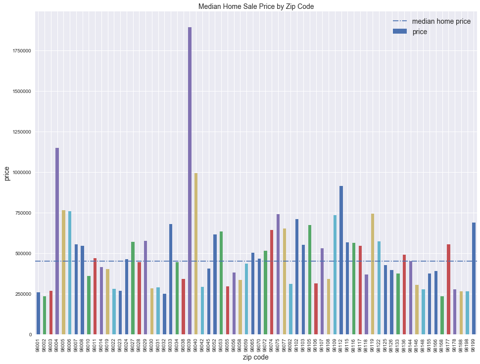

```python
#What is the median home sale price in each zipcode?
fig, ax = plt.subplots(figsize = (16, 12))
df.groupby('zipcode')['price'].median().plot(kind='bar')
ax.axhline(y = df['price'].median(),linestyle='-.', label = 'median home price' )
plt.xlabel('zip code', fontsize = 14)
plt.ylabel('price', fontsize = 14)
plt.title('Median Home Sale Price by Zip Code',fontsize = 14)
plt.legend(fontsize = 14)
plt.show()
```

Which zip code has the highest average home value?

Zip code 98039 is the most expensive zipcode with an average Home sale price of 2,161,300 million dollars (median 1,895,000 million dollars). Earlier we saw that most home sales are in zip code 98103 with 602 homes sold. The average price of homes in zipcode 98103 is 585,048 USD (median 550,000 USD). '''df.groupby('zipcode')['price'].mean() ''' '''df.groupby('zipcode')['price'].median()'''

What are the features of the mediam homes sold in King County?

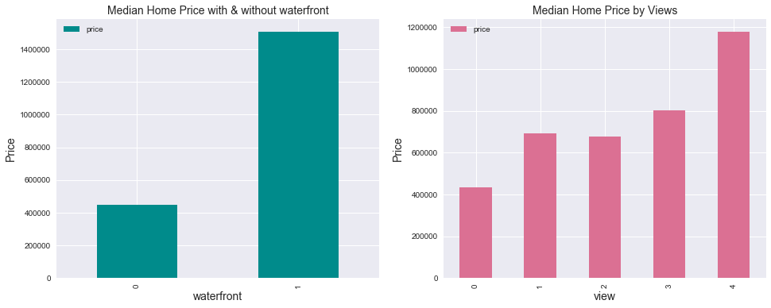

```python
# Are the mediam home sales in KC located on the waterfront and have nice views?
# Let us use the Median Sale Price instead of the Mean Sale price at this time as we have not explored any price outliers that may skew the data

fig, axes = plt.subplots(ncols=2, nrows=1, figsize=(16, 6))

waterfront_pivot = df.pivot_table(index='waterfront', values='price', aggfunc=np.median)
waterfront_pivot.plot(kind='bar', color='darkcyan', ax=axes[0])
axes[0].set_xlabel('waterfront',fontsize =14)
axes[0].set_ylabel('Price', fontsize =14)
axes[0].set_title('Median Home Price with & without waterfront', fontsize =14)
# axes[0].set_xticklabels(axes.get_xticklabels(),rotation=0)
# axes[0].set_xticks(rotation=180)


view_pivot = df.pivot_table(index='view', values='price', aggfunc=np.median)
view_pivot.plot(kind='bar', color='PALEVIOLETRED', ax=axes[1])
axes[1].set_xlabel('view',fontsize =14)
axes[1].set_ylabel('Price', fontsize =14)
axes[1].set_title('Median Home Price by Views', fontsize =14)

plt.show()
```

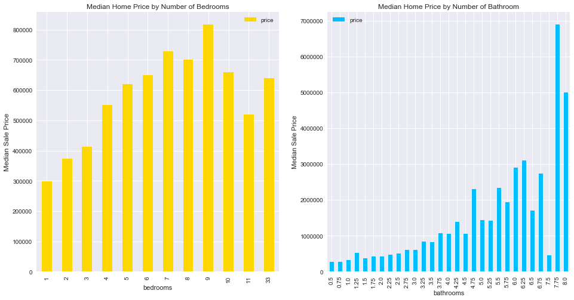

```python
# Do more bedrooms or bathrooms add value to home sales?
# Let us use the Median Sale Price instead of the Mean Sale price at this time as we have not explored any outliers that may be skew the data
fig, axes = plt.subplots(ncols=2, nrows=1, figsize=(16, 8))

bedroom_pivot = df.pivot_table(index='bedrooms', values='price', aggfunc=np.median)
bedroom_pivot.plot(kind='bar', color='gold', ax=axes[0])
axes[0].set_xlabel('bedrooms')
axes[0].set_ylabel('Median Sale Price', fontsize =12)
axes[0].set_title('Median Home Price by Number of Bedrooms')
#axes[0].set_xticklabels(which='both', rotation=90)
#axes[0].set_xticklabels(axes.get_xticklabels(),rotation=0)
#axes[0].set_xticks(rotation=0)

bathroom_pivot = df.pivot_table(index='bathrooms', values='price', aggfunc=np.median)
bathroom_pivot.plot(kind='bar', color='deepskyblue', ax=axes[1])
axes[1].set_xlabel('bathrooms')
axes[1].set_ylabel('Median Sale Price')
axes[1].set_title('Median Home Price by Number of Bathroom')
#axes[1].set_xticklabels(rotation=90)
plt.show()
```

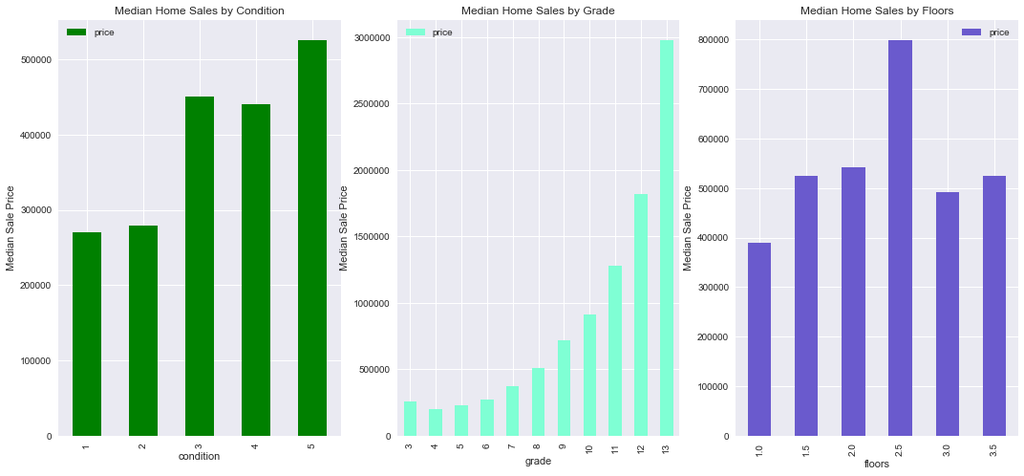

```python
#What are the conditions, number of floors and quality of constructions of the homes sold?
fig, axes = plt.subplots(ncols=3, nrows=1, figsize=(18, 8))

condition_pivot = df.pivot_table(index='condition', values='price', aggfunc=np.median)
condition_pivot.plot(kind='bar', color='green', ax=axes[0])
axes[0].set_xlabel('condition')
axes[0].set_ylabel('Median Sale Price')
#plt.xticks(rotation=0)
axes[0].set_title('Median Home Sales by Condition')


grade_pivot = df.pivot_table(index='grade', values='price', aggfunc=np.median)
grade_pivot.plot(kind='bar', color='aquamarine', ax=axes[1])
axes[1].set_xlabel('grade')
axes[1].set_ylabel('Median Sale Price')
axes[1].set_title('Median Home Sales by Grade')
#plt.xticks(rotation=0)

floors_pivot = df.pivot_table(index='floors', values='price', aggfunc=np.median)
floors_pivot.plot(kind='bar', color='slateblue', ax=axes[2])
axes[2].set_xlabel('floors')
axes[2].set_ylabel('Median Sale Price')
axes[2].set_title('Median Home Sales by Floors')
#plt.xticks(rotation=0)
plt.show()
```

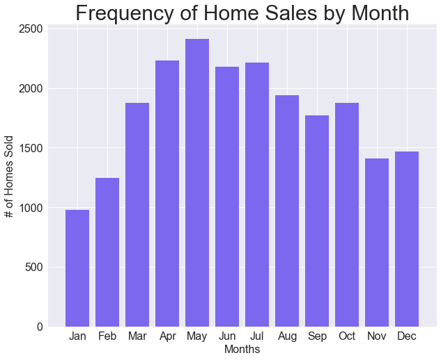

```python
df.date = pd.to_datetime(df.date)
months = ['Jan','Feb','Mar','Apr','May','Jun','Jul','Aug','Sep','Oct','Nov','Dec']
sales_cnt = []
for mo in range(1,13):
    sales_cnt.append(sum(df.date.dt.month == mo))

plt.figure(figsize=(10,8))
plt.xticks(rotation = 0,fontsize =16)
plt.yticks(fontsize =16)
plt.bar(months, sales_cnt, color='mediumslateblue')
plt.xlabel('Months',fontsize =16)
plt.ylabel('# of Homes Sold', fontsize =16)
plt.title('Frequency of Home Sales by Month',fontsize =30)
plt.show()
```

```python
# #Do not delete- use this to generate charts for presentation slides
# bedroom_pivot = df.pivot_table(index='bedrooms', values='price', aggfunc=np.median)
# bedroom_pivot.plot(kind='bar', color='gold',figsize=(16, 10))
# plt.xticks(rotation = 0,fontsize =16)
# plt.yticks(fontsize =16)
# plt.xlabel('bedrooms', fontsize =16)
# plt.ylabel('Median Sale Price', fontsize =16)
# plt.title('Median Home Price by Number of Bedrooms',fontsize =30)
# plt.show()

# bathroom_pivot = df.pivot_table(index='bathrooms', values='price', aggfunc=np.median)
# bathroom_pivot.plot(kind='bar', color='deepskyblue',figsize=(16, 10))
# plt.xticks(rotation = 0,fontsize =16)
# plt.yticks(fontsize =16)
# plt.xlabel('bathrooms', fontsize =16)
# plt.ylabel('Median Sale Price', fontsize =16)
# plt.title('Median Home Price by Number of Bathrooms',fontsize =30)
# plt.show()

# condition_pivot = df.pivot_table(index='condition', values='price', aggfunc=np.median)
# condition_pivot.plot(kind='bar', color='green', figsize=(16, 10))
# plt.xticks(rotation = 0,fontsize =16)
# plt.yticks(fontsize =16)
# plt.xlabel('condition',fontsize =16)
# plt.ylabel('Median Sale Price', fontsize =16)
# plt.title('Median Home Sales by Condition',fontsize =30)
# plt.show()


# grade_pivot = df.pivot_table(index='grade', values='price', aggfunc=np.median)
# grade_pivot.plot(kind='bar', color='aquamarine', figsize=(16, 10))
# plt.xticks(rotation = 0,fontsize =16)
# plt.yticks(fontsize =16)
# plt.xlabel('grade')
# plt.ylabel('Median Sale Price', fontsize =16)
# plt.title('Median Home Sales by Grade',fontsize =30)
# plt.legend()
# plt.show()


# floors_pivot = df.pivot_table(index='floors', values='price', aggfunc=np.median)
# floors_pivot.plot(kind='bar', color='slateblue', figsize=(16, 10))
# plt.xticks(rotation = 0,fontsize =16)
# plt.yticks(fontsize =16)
# plt.xlabel('floors')
# plt.ylabel('Median Sale Price', fontsize =16)
# plt.title('Median Home Sales by Floors',fontsize =30)
# plt.legend()
# plt.show()

# plt.figure(figsize=(16,12))
# plt.plot(df.groupby('yr_built').agg({'yr_built': 'count'}))
# plt.xticks(rotation = 0,fontsize =16)
# plt.yticks(fontsize =16)
# plt.xlabel('year built',fontsize =16)
# plt.ylabel('# of Homes Built', fontsize =16)
# plt.title('Number of Houses built from 1900-2014',fontsize =30)
# plt.show()


# df['yr_built'].value_counts()[:70].plot(kind='bar', figsize=(16, 10))
# plt.xticks(rotation = 90,fontsize =13)
# plt.yticks(fontsize =16)
# plt.title('Number of Homes Built by Year',fontsize =30)
# plt.show()
```

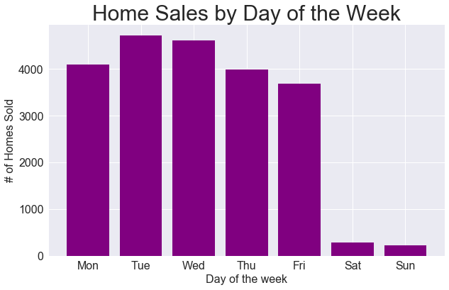

```python
#Which day of the week is best for selling your home in Kings County
day_week = ['Mon','Tue','Wed','Thu','Fri','Sat','Sun']
sales_day = []

for d in range(0,7):
    sales_day.append(sum(df.date.dt.dayofweek == d))

plt.figure(figsize=(10,6))
plt.xticks(rotation = 0,fontsize =16)
plt.yticks(fontsize =16)
plt.xlabel('Day of the week',fontsize =16)
plt.ylabel('# of Homes Sold', fontsize =16)
plt.bar(day_week,sales_day, color = 'purple')
plt.title('Home Sales by Day of the Week',fontsize =30)
plt.show()
```

- more funds are available for repairs and renovations with tax refund money available around this time
- more home buyers go out searching for homes with the warmer weather plus the curb appeal that spring and summer months offer when the trees, flowers and grass bloom
- warmer weather is the best time to move with more daylight hours, as well as allowing kids to finish the school year as buyers close on a home/sellers have more time for showings
- sense of urgency for buyers to get their school-aged kids settled What is the single best day where the highest number of homes were sold at King County?

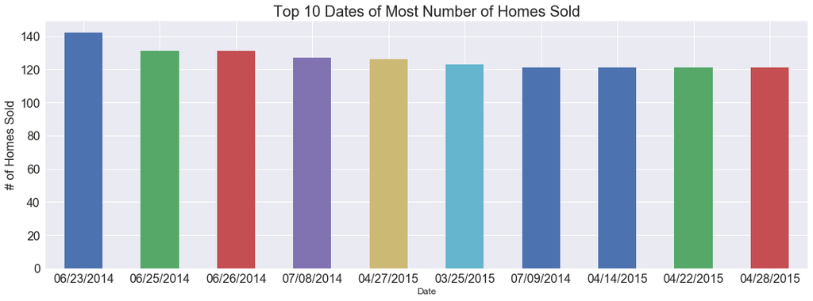

```python
df['date']=pd.to_datetime(df["date"]).dt.strftime('%m/%d/%Y')
mhs= df.groupby('date').agg({'date': 'count'})
mhs = mhs.date.sort_values(ascending=False).head(10)

mhs.plot(kind='bar', figsize=(18,6), fontsize=16)
plt.title('Top 10 Dates of Most Number of Homes Sold', fontsize=20)
plt.xlabel('Date',fontsize =12)
plt.ylabel('# of Homes Sold', fontsize =16)
plt.xticks(rotation = 0,fontsize =16)
plt.show()
```

```python
#Let's check the dates were most homes were sold in a single day
mhs
```

```
date
06/23/2014    142
06/25/2014    131
06/26/2014    131
07/08/2014    127
04/27/2015    126
03/25/2015    123
07/09/2014    121
04/14/2015    121
04/22/2015    121
04/28/2015    121
Name: date, dtype: int64
```

The Top 2 highest number of homes sold in a single day occurred in the last week of June 2014 on 6/23/2014 with 142 homes sold, followed by 6/25 & 6/26 (tied) with 131 homes sold. The top 10 highest single day sales happened in the summer of 2014 and spring 2015.

```python
#We will no longer use date in the exploratory data analysis and will remove it from the data set
df.drop('date', axis=1, inplace=True)
```

[**`pandas.DataFrame.drop`**](http://pandas.pydata.org/pandas-docs/stable/generated/pandas.DataFrame.drop.html)

[Jump back to Table of Contents]

### 3b. Outliers Check

```python
#Let's check % of outliers https://www.kaggle.com/prasadperera/the-boston-housing-dataset
ncategoricals = dfc.select_dtypes(include=[np.number])
for k, v in ncategoricals.items():
        q1 = v.quantile(0.25)
        q3 = v.quantile(0.75)
        irq = q3 - q1
        v_col = v[(v <= q1 - 1.5 * irq) | (v >= q3 + 1.5 * irq)]
        perc = np.shape(v_col)[0] * 100.0 / np.shape(df)[0]
        print("Column %s outliers = %.2f%%" % (k, perc))
```

```
Column price outliers = 5.36%
Column sqft_above outliers = 2.86%
Column sqft_basement outliers = 2.59%
Column sqft_living outliers = 2.69%
Column sqft_living15 outliers = 2.51%
Column sqft_lot outliers = 11.20%
Column sqft_lot15 outliers = 10.13%
```

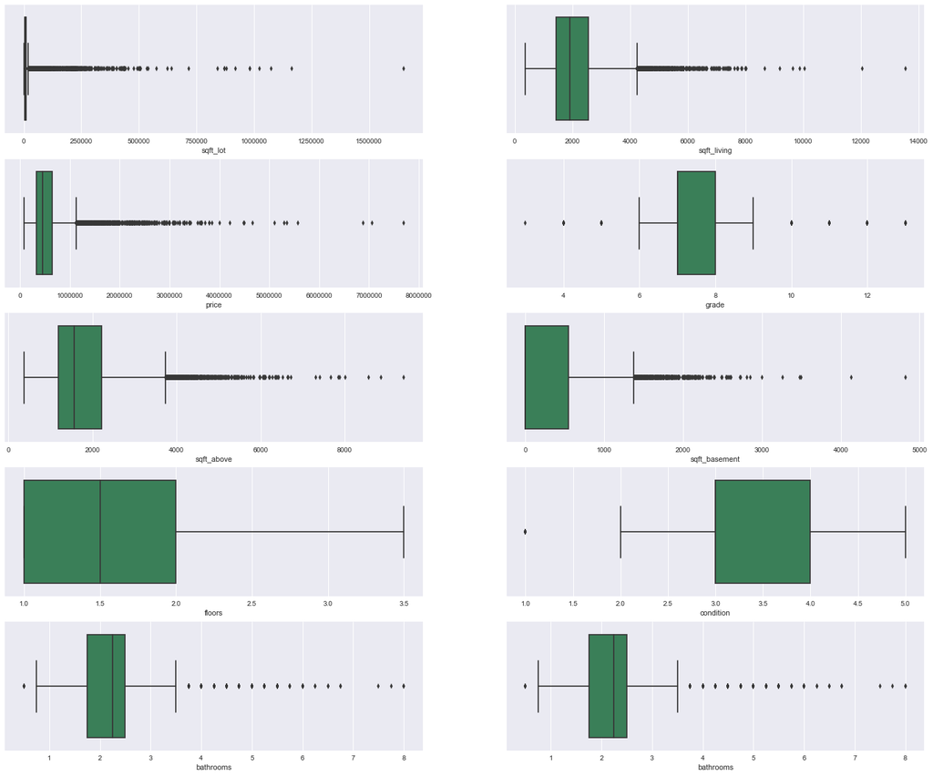

```python
#Let's create boxplots for the predictors to visualize these outliers
#https://stackoverflow.com/questions/23658013/using-matplotlib-show-10-subplots-all-at-once
fig = plt.figure(figsize=(24,20))
a1 = fig.add_subplot(521)
sns.boxplot(df.sqft_lot, color='SEAGREEN')
a2 = fig.add_subplot(522)
sns.boxplot(df.sqft_living, color='SEAGREEN')
a3 = fig.add_subplot(523)
sns.boxplot(df.price, color='SEAGREEN')
a4 = fig.add_subplot(524)
sns.boxplot(df.grade, color='SEAGREEN')
a5 = fig.add_subplot(525)
sns.boxplot(df.sqft_above, color='SEAGREEN')
a6 = fig.add_subplot(526)
sns.boxplot(df.sqft_basement, color='SEAGREEN')
a7 = fig.add_subplot(527)
sns.boxplot(df.floors, color='SEAGREEN')
a8 = fig.add_subplot(528)
sns.boxplot(df.condition, color='SEAGREEN')
a9 = fig.add_subplot(529)
sns.boxplot(df.bathrooms, color='SEAGREEN')
a10 = fig.add_subplot(5,2,10)
sns.boxplot(df.bathrooms, color='SEAGREEN')
```

We can visulaize significant amount of outliers on our data set. We will use the interquartile range (IQR), also called the midspread or middle 50% (H-spread), to measure the statistical dispersion by finding the difference between 75th and 25th percentiles, or between upper and lower quartiles, IQR = Q3 − Q1.

```python
Q1 = df.quantile(0.25)
Q3 = df.quantile(0.75)
IQR = Q3 - Q1
print(IQR) #to get the IQR for each column and get the list of outliers
```

```
bathrooms             0.7500
bedrooms              1.0000
condition             1.0000
floors                1.0000
grade                 1.0000
lat                   0.2069
long                  0.2030
price            323000.0000
sqft_above         1020.0000
sqft_basement       550.0000
sqft_living        1120.0000
sqft_living15       870.0000
sqft_lot           5645.0000
sqft_lot15         4983.0000
view                  0.0000
waterfront            0.0000
yr_built             46.0000
yr_renovated          0.0000
zipcode              85.0000
dtype: float64
```

```python
#Let's check how the shape of our data to visualize how our data will be affected before removing the outliers
df_out = df[~((df < (Q1 - 1.5 * IQR)) |(df > (Q3 + 1.5 * IQR))).any(axis=1)]
df_out.shape
```

```
(14996, 19)
```

Now that we have detected the outliers, we can decide to remove or correct them. Some models do not recommend removing outliers, however, since we are running regression and the assumption of no outliers should be met, we will remove the outliers because they will affect our model accuracy.  
https://towardsdatascience.com/ways-to-detect-and-remove-the-outliers-404d16608dba

```python
#Let's check the descriptive statistics for the new dataset without the outliers
import numpy as np
display(np.round(df_out.iloc[:,0:14].describe(), decimals=2),
np.round(df_out.iloc[:,14:32].describe(), decimals=2))
```

|  | bathrooms | bedrooms | condition | floors | grade | lat | long | price | sqft_above | sqft_basement | sqft_living | sqft_living15 | sqft_lot | sqft_lot15 |
| --- | --- | --- | --- | --- | --- | --- | --- | --- | --- | --- | --- | --- | --- | --- |
| count | 14996.00 | 14996.00 | 14996.00 | 14996.00 | 14996.00 | 14996.00 | 14996.00 | 14996.00 | 14996.00 | 14996.00 | 14996.00 | 14996.00 | 14996.00 | 14996.00 |
| mean | 1.97 | 3.26 | 3.42 | 1.47 | 7.38 | 47.56 | -122.23 | 438595.88 | 1585.09 | 223.26 | 1813.07 | 1795.29 | 6985.91 | 6863.90 |
| std | 0.65 | 0.77 | 0.65 | 0.55 | 0.81 | 0.14 | 0.12 | 180410.22 | 601.39 | 349.08 | 614.14 | 506.79 | 3356.09 | 2988.42 |
| min | 0.75 | 2.00 | 2.00 | 1.00 | 6.00 | 47.19 | -122.47 | 82000.00 | 480.00 | 0.00 | 560.00 | 620.00 | 520.00 | 651.00 |
| 25% | 1.50 | 3.00 | 3.00 | 1.00 | 7.00 | 47.46 | -122.33 | 300000.00 | 1140.00 | 0.00 | 1350.00 | 1430.00 | 4684.75 | 4800.00 |
| 50% | 2.00 | 3.00 | 3.00 | 1.00 | 7.00 | 47.57 | -122.26 | 405000.00 | 1430.00 | 0.00 | 1740.00 | 1700.00 | 7014.00 | 7153.00 |
| 75% | 2.50 | 4.00 | 4.00 | 2.00 | 8.00 | 47.68 | -122.15 | 547500.00 | 1910.00 | 430.00 | 2202.75 | 2090.00 | 8925.00 | 8645.00 |
| max | 3.50 | 5.00 | 5.00 | 3.50 | 9.00 | 47.78 | -121.82 | 1120000.00 | 3740.00 | 1370.00 | 4200.00 | 3640.00 | 19141.00 | 17550.00 |

|  | view | waterfront | yr_built | yr_renovated | zipcode |
| --- | --- | --- | --- | --- | --- |
| count | 14996.0 | 14996.0 | 14996.00 | 14996.0 | 14996.00 |
| mean | 0.0 | 0.0 | 1971.53 | 0.0 | 98079.90 |
| std | 0.0 | 0.0 | 29.36 | 0.0 | 53.49 |
| min | 0.0 | 0.0 | 1900.00 | 0.0 | 98001.00 |
| 25% | 0.0 | 0.0 | 1952.00 | 0.0 | 98033.00 |
| 50% | 0.0 | 0.0 | 1974.00 | 0.0 | 98072.00 |
| 75% | 0.0 | 0.0 | 1999.00 | 0.0 | 98118.00 |
| max | 0.0 | 0.0 | 2015.00 | 0.0 | 98199.00 |

```python
#We can see from the boxplots above that we have many features with outliers (bedrooms, bathrooms, price,lot, living area)
#Let's manually remove the outliers by using the max value in the df.decsribe output above as our guide
print('Number of rows before removing Outliers:',len(df))
# Remove outliers from dataset
df = df[df.bedrooms < 6]
df = df[df.bathrooms < 4]
df = df[df.condition < 6]
df = df[df.floors < 4]
df = df[df.grade <= 11]
df = df[df.sqft_lot < 20000]
df = df[df.sqft_lot15 < 20000]
df = df[df.price < 1500000]
df = df[df.sqft_living15 < 4000]
df = df[df.sqft_living < 5000]
df = df[df.sqft_above < 3500]
print('Number of rows after removing Outliers:',len(df))
```

```
Number of rows before removing Outliers: 21597
Number of rows after removing Outliers: 18011
```

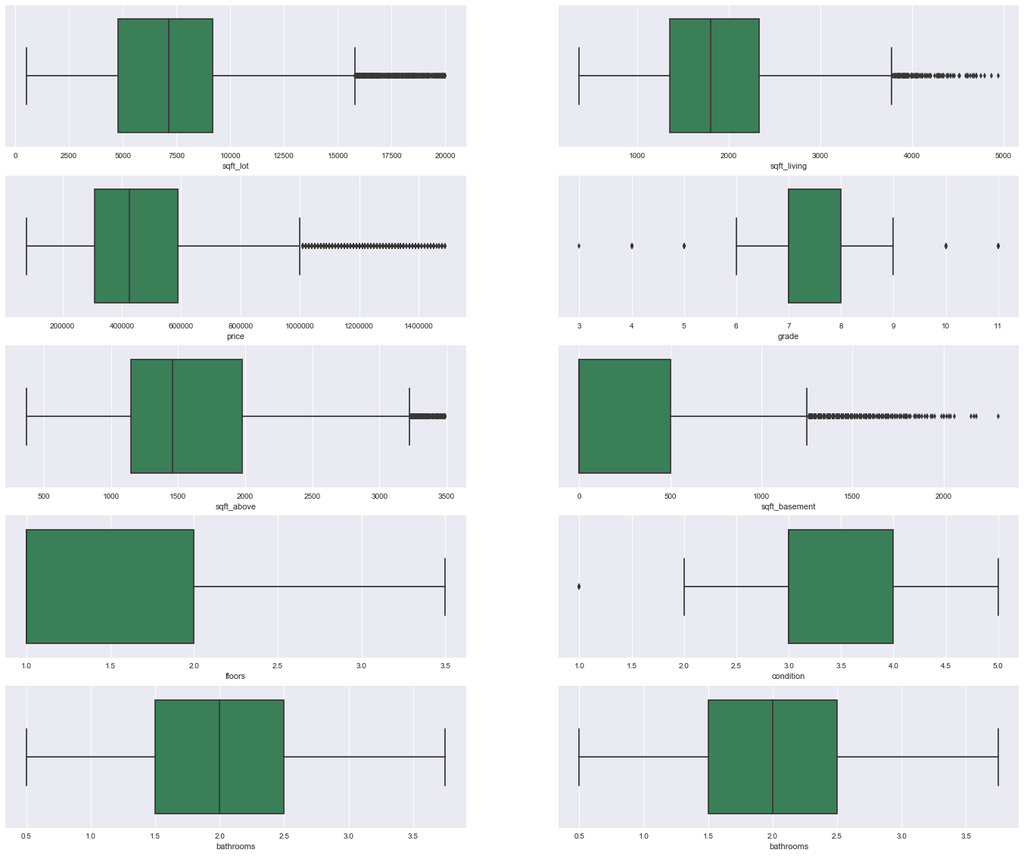

```python
#Let's inspect our data after the outliers are removed
fig = plt.figure(figsize=(24,20))
a1 = fig.add_subplot(521)
sns.boxplot(df.sqft_lot, color='SEAGREEN')
a2 = fig.add_subplot(522)
sns.boxplot(df.sqft_living, color='SEAGREEN')
a3 = fig.add_subplot(523)
sns.boxplot(df.price, color='SEAGREEN')
a4 = fig.add_subplot(524)
sns.boxplot(df.grade, color='SEAGREEN')
a5 = fig.add_subplot(525)
sns.boxplot(df.sqft_above, color='SEAGREEN')
a6 = fig.add_subplot(526)
sns.boxplot(df.sqft_basement, color='SEAGREEN')
a7 = fig.add_subplot(527)
sns.boxplot(df.floors, color='SEAGREEN')
a8 = fig.add_subplot(528)
sns.boxplot(df.condition, color='SEAGREEN')
a9 = fig.add_subplot(529)
sns.boxplot(df.bathrooms, color='SEAGREEN')
a10 = fig.add_subplot(5,2,10)
sns.boxplot(df.bathrooms, color='SEAGREEN')
```

[Jump back to Table of Contents]

### 3c. Linearity check

Linearity assumptions requires that there should be a **linear relationship** between the target/criterion variable (Y) and predictor (X). Linear means that the change in Y by 1-unit change in X, is constant.

If we try to fit a linear model to a non-linear data set, Ordinary Least Squares (OLS) would fail to capture the trend mathematically. This will result in an inaccurate relationship and wrong predictions on an unseen data set.

The linearity assumption can best be tested with scatter plots. Outliers are revealed in a scatter plot and need to be dealt with as it will introduce bias that will prevent the model from providing accurate estimates on the relationships between variables.

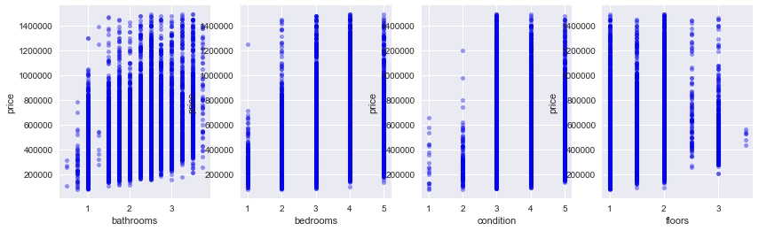

```python
#Create a scatterplot of  the variables
fig, axes = plt.subplots(nrows=1, ncols=4, figsize=(14,4))

for xcol, ax in zip(list(df)[0:4], axes):
    df.plot(kind='scatter', x= xcol, y="price", ax=ax, alpha=0.4, color='b')
```

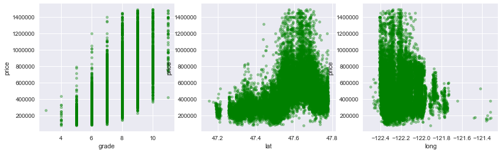

```python
fig, axes = plt.subplots(nrows=1, ncols=3, figsize=(14,4))

for xcol, ax in zip(list(df)[4:8], axes):
    df.plot(kind='scatter', x= xcol, y="price", ax=ax, alpha=0.4, color='g')
```

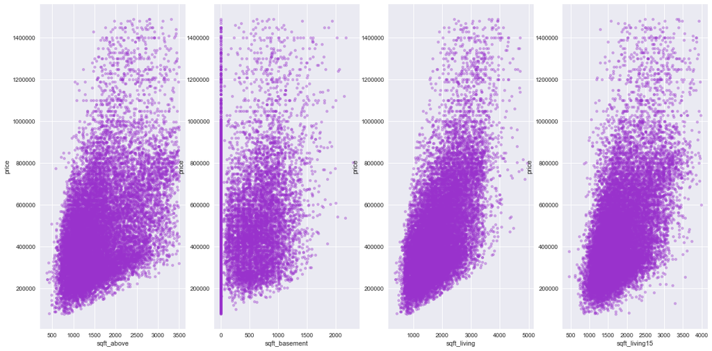

```python
fig, axes = plt.subplots(nrows=1, ncols=4, figsize=(20,10))

for xcol, ax in zip(list(df)[8:12], axes):
    df.plot(kind='scatter', x= xcol, y="price", ax=ax, alpha=0.4, color='darkorchid')
```

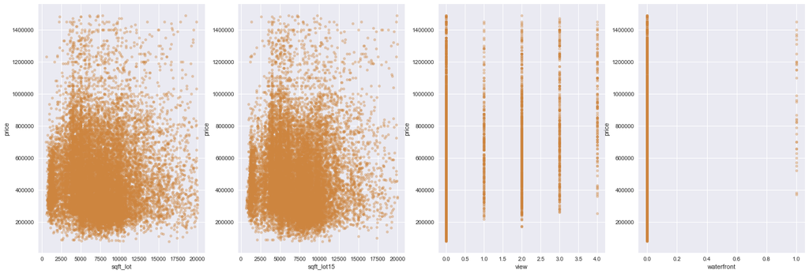

```python
fig, axes = plt.subplots(nrows=1, ncols=4, figsize=(24,8))

for xcol, ax in zip(list(df)[12:16], axes):
    df.plot(kind='scatter', x= xcol, y="price", ax=ax, alpha=0.4, color='peru')
```

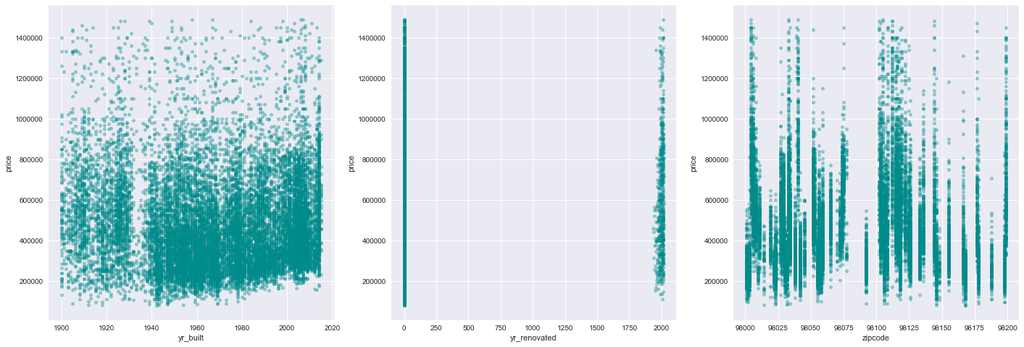

```python
fig, axes = plt.subplots(nrows=1, ncols=3, figsize=(24,8))

for xcol, ax in zip(list(df)[16:20], axes):
    df.plot(kind='scatter', x= xcol, y="price", ax=ax, alpha=0.4, color='darkcyan')
```

Scatter plot Linearity Interpretation: How does the features relate to the home sale price?

```
+ There is a very strong linear relationship between the sqft_living, sqft_living15, sqft_above, bathrooms, grade and price. The positive relationship shows that sqt_living and price are correlated.
+ As the number of bedrooms increase, there is a rising trend in housing prices (not a linear trend).
+ There is unit increases in price with increasing the floors and home condition
+ There is a weak positive correlation between sqft_basement and sales price
+ There is vague relationship between prices and yr_built, yr_renovated, and sqft lot/lot15
+ Due to the many linear relationships, we can apply regression models
+ There are outliers in both dependent and independent variables
```

[Jump back to Table of Contents]

### 3d. Normality check

```
price Skew is: 4.023364652271239 Kurtosis is: 34.54135857673376
sqft_above Skew is: 1.4474342353857224 Kurtosis is: 3.405519761077342
sqft_basement Skew is: 1.6052718354702864 Kurtosis is: 2.8136290993171076
sqft_living Skew is: 1.473215455425834 Kurtosis is: 5.252101950846816
sqft_living15 Skew is: 1.1068753971161713 Kurtosis is: 1.591732789053459
sqft_lot Skew is: 13.072603567136046 Kurtosis is: 285.49581188504857
sqft_lot15 Skew is: 9.524361965117942 Kurtosis is: 151.39566252348297
```

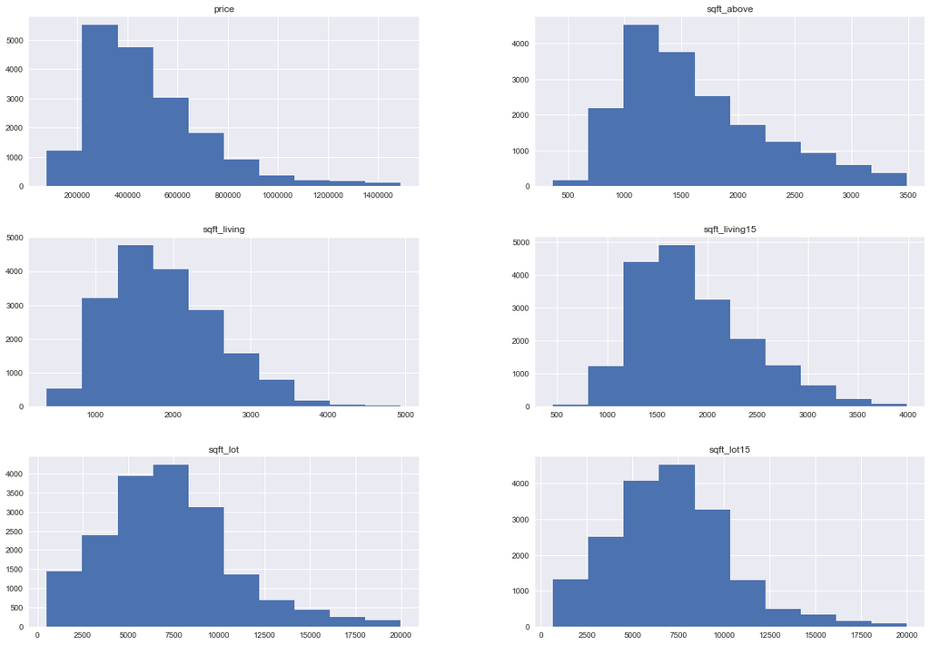

```python
#plot a histogram for the continuous variables to see their distributions
df[['price','sqft_living','sqft_living15','sqft_lot','sqft_lot15','sqft_above']].hist(figsize=(20,14))

numeric_features = dfc.select_dtypes(include=[np.number])
for col in numeric_features:
    print (col, "Skew is:", dfc[col].skew(), "Kurtosis is:", dfc[col].kurtosis())
#check for skewness & kurtosis
```

Home sale prices increase with the increase of sqft_living.

  Kurtosis is the 4th moment in statistics. It tells you the height and sharpness of the central peak, relative to that of a standard bell curve.
  - A positive value tells you that you have heavy-tails (i.e. a lot of data in your tails).
  - A negative value means that you have light-tails (i.e. little data in your tails).
  - This heaviness or lightness in the tails usually means that your data looks flatter (or less flat) compared to the normal distribution. The standard normal distribution has a kurtosis of 3, so if your values are close to that then your graph’s tails are nearly normal. These distributions are called mesokurtic.

Why transform? to reduce skewness, to have equal spreads, to prove linear relationships and additive relationships

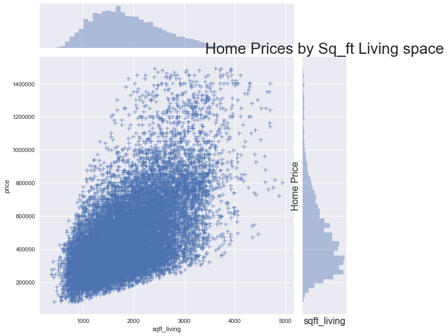

```python
sns.jointplot('sqft_living','price', data=df, height=8, alpha=.5, marker='+')

plt.xticks(rotation = 0,fontsize =16)
plt.yticks(fontsize =16)
plt.xlabel('sqft_living',fontsize =16)
plt.ylabel('Home Price', fontsize =16)
plt.title('Home Prices by Sq_ft Living space',fontsize =26)
plt.show()
```

[**`seaborn.distplot`**](https://seaborn.pydata.org/generated/seaborn.distplot.html)

[Jump back to Table of Contents]

We would hold off log transformation for now. Let's identify presence of multicollinearity, remove highly correlated valriables before we transform.

### 3e. Multicollinearity check

In feature selection for a regression model, it is important to check for multicollinearity.  
Multicollinearity means that some of the independent variables (regressors) are highly correlated with each other. If the regressors are highly correlated, it will be difficult to find the correct predictors and their precise effect on the target and may reduce the accuracy of the regression estimates.

```python
#Create a dataframe for the transformed and scaled features by dropping the target variable
df_pred = df.drop(['price'], axis = 1)
```

```python
#Create a dataframe for the target variable
df_target = pd.DataFrame(df, columns = ['price'])
```

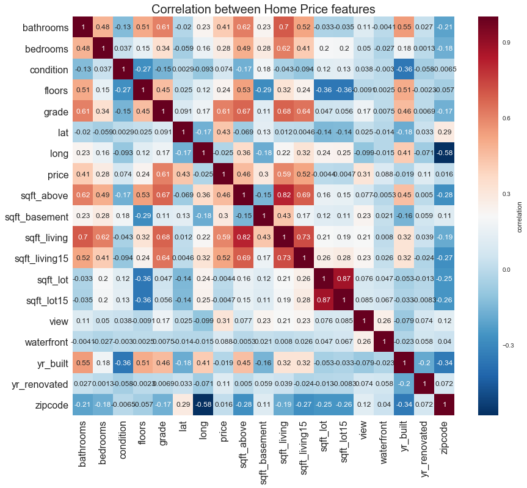

```python
plt.figure(figsize=(14,12))
# Compute the correlation matrix

sns.heatmap(df.corr(), cmap = 'RdBu_r', annot = True, annot_kws={'size': 12},
          cbar=True,  cbar_kws = {'label' : 'correlation'});
plt.title('Correlation between Home Price features', fontdict={'fontsize': 20})

plt.xticks(rotation = 90,fontsize =16)
plt.yticks(fontsize =16)
# plt.xlabel(fontsize =16)
#plt.ylabel('Home Price', fontsize =16)
plt.show()
```

Pearson's Correlation Coefficient or linear correlation coefficient measures the strength and the direction of linear relationship between two variables. Correlation is a technique for investigating the relationship between two quantitative, continuous variables, for example, price and sqft_living. Pearson's correlation coefficient (r) is a measure of the strength of the association between the two variables.  
Pearson's r is sensitive to outliers, which can have a very large effect on the line of best fit and  
the Pearson correlation coefficient, leading to very difficult conclusions regarding your data. Therefore, it is best if there are no outliers or they are kept to a minimum.  
Assumption #1: Your two variables should be measured at the continuous level.  
Assumption #2: There needs to be a linear relationship between your two variables.  
Assumption #3: There should be no significant outliers.  
Assumption #4: The variables should be approximately normally distributed.  
Create a new DataFrame that only has the continuous variables

[**`pandas.concat`**](http://pandas.pydata.org/pandas-docs/stable/generated/pandas.concat.html)

```python
#display(df_pred.corr())
#abs(df.corr()) > 0.75
```

```python
df.corr()['price'].sort_values(ascending=False)
```

```
price            1.000000
grade            0.606752
sqft_living      0.593957
sqft_living15    0.521543
sqft_above       0.462078
lat              0.427440
bathrooms        0.411347
view             0.312771
sqft_basement    0.296162
bedrooms         0.277410
floors           0.238914
yr_renovated     0.112450
waterfront       0.088348
condition        0.073965
zipcode          0.016063
sqft_lot        -0.004381
sqft_lot15      -0.004707
yr_built        -0.018511
long            -0.024562
Name: price, dtype: float64
```

Multicollinearity occurs when independent variables in a regression model are correlated, i.e. indicates that changes in one predictor are associated with changes in another one as well. This correlation  
is a problem because the idea behind regression is that you can change one variable and keep the others constant. If the degree of correlation between variables is high enough, it can cause problems when you fit the model and interpret the results.  
Generally, a correlation with an absolute value around 0.7-0.8 or higher is considered a high correlation.  
We used 0.70 as a cut-off, how many high correlations do we have?

However, the highest correlation exists between sqft_lot and sqft_lot15 at 0.87 followed by sqft_above and sqft_living.  
We will go ahead and remove sqft_above and sqft_lot15.

```python
#We will drop one of independent variables that are highly correlated to each other.
df.drop(['sqft_above','sqft_lot15'], axis=1, inplace=True)
```

[Jump back to Table of Contents]

## 4. Modeling the Data

So far we have only dealt with outliers. We can improve upon the results by pre-processing the data further thru normalizing data and scaling values to help get more meaningful results.

**The Pearson Correlation (range: -1 -> 1) is a standard way to describe the correlation between two variables Statistical learning theory deals with the problem of finding a predictive function based on data A loss function calculates how well a given model represents the relationship between data values A linear regression is simply a (straight) line of best fit for predicting a continuous value (y = mx + c) The Coefficient of Determination (R Squared) can be used to determine how well a given line fits a given data set Certain assumptions must hold true for a least squares linear regression to be useful - linearity, normality and heteroscedasticity Q-Q plots can check for normality in residual errors The Jarque-Bera test can be used to test for normality - especially when the number of data points is large The Goldfeld-Quant test can be used to check for homoscedasticity**

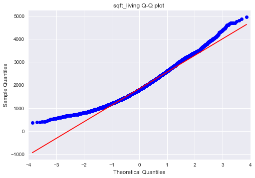

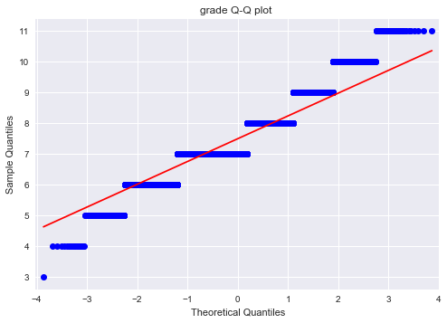

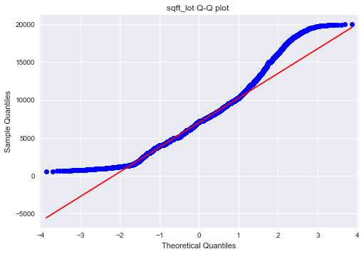

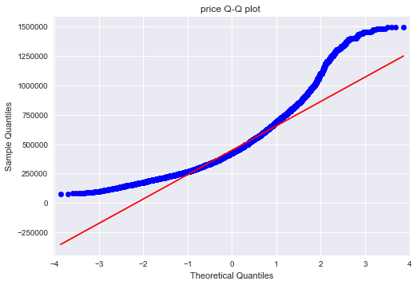

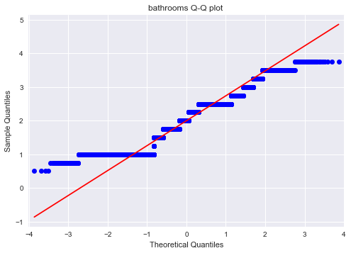

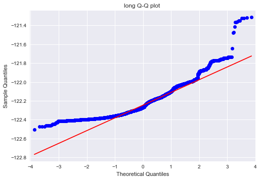

```python
data = df.sqft_living
qqplot(data, line = 'q')
plt.title('sqft_living Q-Q plot ')
plt.show()

data = df.grade
qqplot(data, line = 'q')
plt.title('grade Q-Q plot ')
plt.show()

data = df.sqft_lot
qqplot(data, line = 'q')
plt.title('sqft_lot Q-Q plot ')
plt.show()

data = df.price
qqplot(data, line = 'q')
plt.title('price Q-Q plot ')
plt.show()

data = df.bathrooms
qqplot(data, line = 'q')
plt.title('bathrooms Q-Q plot ')
plt.show()

data = df.long
qqplot(data, line = 'q')
plt.title('long Q-Q plot ')
plt.show()
```

Another way to check for normality assumption is with a Q-Q-Plot(quantile-quantile) plot, a probability plot, which is a graphical method for comparing two probability distributions by plotting their quantiles against each other.

We are using the Q-Q plot for regression as a visual check to see the overall shape of data against required distribution. We can see how the quantiles of normal data appear as a straight line along the diagonal when plotted against a standard normal distribution's quantiles. The skewness and kurtosis of data can also be inspected.

In section I-D [Inspect the unique column values] , we have reviewed all the other categorical features. Let's convert the rest to categorical data types.

```python
#let's change the data types of our categorical variables

categorical = [ 'condition', 'floors','grade', 'view', 'waterfront', 'yr_built' ,'zipcode', 'yr_renovated',
               'bedrooms','bathrooms','lat','long']

for cat in categorical:
    df[cat] = df[cat].astype('category')

#we need to convert to int , then category so we will not encounter problems with creating the dummy variable for bathrooms
df.bathrooms = df.bathrooms.astype('int').astype('category')

#Let's check the new data types
print('Converted Datatype','\n','===================')
for cat in categorical:
    print(cat,'(',df[cat].dtype,')')
```

```
Converted Datatype
 ===================
condition ( category )
floors ( category )
grade ( category )
view ( category )
waterfront ( category )
yr_built ( category )
zipcode ( category )
yr_renovated ( category )
bedrooms ( category )
bathrooms ( category )
lat ( category )
long ( category )
```

```python
#We will use for-loop to look at some results for each linear regression model
X = df.drop('price', axis = 1)
y = pd.DataFrame(df, columns = ['price'])

columns = df.describe().columns.drop(['price'])
results = [['variable', 'r_sqr', 'intercept', 'slope', 'p_value']]
for x, val in enumerate(columns):
    print ("price~" + val)
    print ("------------------------------")

    f = 'price~' + val
    model = smf.ols(formula=f, data=df).fit()
    X_new = pd.DataFrame({val: [df[val].min(), df[val].max()]});
    preds = model.predict(X_new)
    results.append([val, model.rsquared, model.params[0], model.params[1], model.pvalues[1]])

    print(results[x + 1])
    print('\n')
```

```
price~sqft_basement
------------------------------
['sqft_basement', 0.08771169982702787, 430111.03199917753, 170.85174519627722, 0.0]


price~sqft_living
------------------------------
['sqft_living', 0.352785096014976, 103590.00898832193, 197.00265380937037, 0.0]


price~sqft_living15
------------------------------
['sqft_living15', 0.2720074574049426, 78727.10697536834, 213.88141960411258, 0.0]


price~sqft_lot
------------------------------
['sqft_lot', 1.9197004529347694e-05, 476928.6147023268, -0.2800950783326517, 0.5565502298388194]
```

```python
#Let's view the above result in a dataframe and save to a list
resultsdf = pd.DataFrame(results)

new_header = resultsdf.iloc[0] #grab the first row for the header
resultsdf = resultsdf[1:] #take the data less the header row
resultsdf.columns = new_header #set the header row as the df header
display(resultsdf[resultsdf.r_sqr < 0.01])
display(resultsdf[resultsdf.p_value == 0])
display(resultsdf[(resultsdf.p_value < 0.05) & (resultsdf.r_sqr > 0.1)])
resultsdf.to_csv('results_data.csv')
```

|  | variable | r_sqr | intercept | slope | p_value |
| --- | --- | --- | --- | --- | --- |
| 4 | sqft_lot | 1.9197e-05 | 476929 | -0.280095 | 0.55655 |

|  | variable | r_sqr | intercept | slope | p_value |
| --- | --- | --- | --- | --- | --- |
| 1 | sqft_basement | 0.0877117 | 430111 | 170.852 | 0 |
| 2 | sqft_living | 0.352785 | 103590 | 197.003 | 0 |
| 3 | sqft_living15 | 0.272007 | 78727.1 | 213.881 | 0 |

|  | variable | r_sqr | intercept | slope | p_value |
| --- | --- | --- | --- | --- | --- |
| 2 | sqft_living | 0.352785 | 103590 | 197.003 | 0 |
| 3 | sqft_living15 | 0.272007 | 78727.1 | 213.881 | 0 |

- sqft_living, sqft_living15, sqft_basement have p-values =0.
- Most of the features have low p-values except for sqft_lot with p-value > 0.05.
- The r-squared values are very low. The highest r squared values we have are for sqft_living & sqft_living15  
  **The R-squared values are low suggesting low correlation between each variable and price.**

```python
np.log(df['price']).describe()
```

```
count    18011.000000
mean        12.965143
std          0.459914
min         11.264464
25%         12.641097
50%         12.959844
75%         13.284482
max         14.214287
Name: price, dtype: float64
```

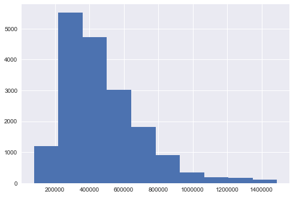

```python
df['price'].hist()
```

```python
#There are no negative values, so let's go ahead with log transform
df_log = df.copy()
df_log['price']  = np.log(df_log['price'])
```

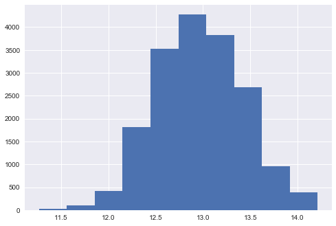

```python
#let's compare the lof transforned variable
df_log['price'].hist()
```

```python
#Let's re-run the linear regression model and see if there are any changes
columns = df_log.describe().columns.drop(['price'])
results_log = [['variable', 'r_sqr', 'intercept', 'slope', 'p_value']]
for x, val in enumerate(columns):
    print ("price~" + val)
    print ("------------------------------")
    print(x)
    f = 'price~' + val
    model = smf.ols(f, df_log).fit()
    X_new = pd.DataFrame({val: [df_log[val].min(), df_log[val].max()]})
    pred = model.predict(X_new)
    results_log.append([val, model.rsquared, model.params[0], model.params[1], model.pvalues[1] ])
    print(results_log[x + 1])
```

```
price~sqft_basement
------------------------------
0
['sqft_basement', 0.08322510948859563, 12.877184302260206, 0.00033549435283202356, 0.0]
price~sqft_living
------------------------------
1
['sqft_living', 0.34810606867447724, 12.221593737270783, 0.00039449375304788847, 0.0]
price~sqft_living15
------------------------------
2
['sqft_living15', 0.27238469387998354, 12.165938697802334, 0.0004314608290005469, 0.0]
price~sqft_lot
------------------------------
3
['sqft_lot', 0.0013994205619156652, 12.999985106865806, -4.820923507221214e-06, 5.117248138279703e-07]
```

```python
resultsdf_log = pd.DataFrame(results_log)#.to_csv('results1_data.csv')

newlog_header = resultsdf_log.iloc[0] #grab the first row for the header
resultsdflog = resultsdf_log[1:] #take the data less the header row
resultsdflog.columns = newlog_header #set the header row as the df header
display(resultsdflog[resultsdflog.r_sqr < 0.01])
display(resultsdflog[resultsdflog.p_value == 0])
display(resultsdflog[(resultsdflog.p_value < -0.05) & (resultsdflog.p_value > 0.05)])
```

|  | variable | r_sqr | intercept | slope | p_value |
| --- | --- | --- | --- | --- | --- |
| 4 | sqft_lot | 0.00139942 | 13 | -4.82092e-06 | 5.11725e-07 |

|  | variable | r_sqr | intercept | slope | p_value |
| --- | --- | --- | --- | --- | --- |
| 1 | sqft_basement | 0.0832251 | 12.8772 | 0.000335494 | 0 |
| 2 | sqft_living | 0.348106 | 12.2216 | 0.000394494 | 0 |
| 3 | sqft_living15 | 0.272385 | 12.1659 | 0.000431461 | 0 |

|  | variable | r_sqr | intercept | slope | p_value |
| --- | --- | --- | --- | --- | --- |

```python
combresult = pd.concat([resultsdf, resultsdf_log], axis=1, sort=False)
combresult.drop([0], axis=0, inplace=True)
combresult.rename(columns={0:'var2', 1:'rsqr2', 2:'interc2', 3:'slope2', 4:'pval2'}, inplace=True)
combresult.head(10)
```

|  | variable | r_sqr | intercept | slope | p_value | var2 | rsqr2 | interc2 | slope2 | pval2 |
| --- | --- | --- | --- | --- | --- | --- | --- | --- | --- | --- |
| 1 | sqft_basement | 0.0877117 | 430111 | 170.852 | 0 | sqft_basement | 0.0832251 | 12.8772 | 0.000335494 | 0 |
| 2 | sqft_living | 0.352785 | 103590 | 197.003 | 0 | sqft_living | 0.348106 | 12.2216 | 0.000394494 | 0 |
| 3 | sqft_living15 | 0.272007 | 78727.1 | 213.881 | 0 | sqft_living15 | 0.272385 | 12.1659 | 0.000431461 | 0 |
| 4 | sqft_lot | 1.9197e-05 | 476929 | -0.280095 | 0.55655 | sqft_lot | 0.00139942 | 13 | -4.82092e-06 | 5.11725e-07 |

[Jump back to Table of Contents]

### 4a. Preprocess the Dummy Variables

We need to transform the categorical variables before using them in regression models. We will be using the dummy variables / one-hot-encoding approach. Also, for independent variables that display as vertical columns structure, instead of cloud structure, we will need to restructure the data into bins to help show a linear pattern between the predictors and target.

```python
#first, create bins for homes that have basements or do not have basements
bins = [ -1 , 1 , df.sqft_basement.astype('int').max() ] # to resolve error 'bins must increase monotonically.'
labels = ['0','1']
df.sqft_basement = pd.cut(df.sqft_basement, bins=bins,labels=labels)

#change to category data type
df.sqft_basement = df.sqft_basement.astype('category')

#Change the sqft_basement column over to dummies, remove the original column from the data, and add the dummy column
dumsqft_basement = pd.get_dummies(df.sqft_basement, prefix='basement', drop_first=True)
df = pd.concat([df, dumsqft_basement], axis = 1)
df.drop(['sqft_basement'], axis=1, inplace=True)
```

```python
#first, create bins for homes that are renovated or not renovated
bins = [ -1 , 1 , df.yr_renovated.astype('int').max() ]
labels = ['0','1']

df.yr_renovated = pd.cut(df.yr_renovated, bins=bins, labels=labels)

#change to category data type
df.yr_renovated = df.yr_renovated.astype('category')

#Change the yr_renovated column over to dummies, remove the original column from the data, and add the dummy column
dumyr_renovated = pd.get_dummies(df.yr_renovated, prefix='renovated', drop_first=True)
df = pd.concat([df,dumyr_renovated], axis = 1)
df.drop(['yr_renovated'], axis=1, inplace=True)
```

```python
#first, create bins for lat & long
bins = list(np.linspace(df.long.astype('int').min(), df.long.astype('int').max(), num=10))
labels = [i for i in range(1,10)]
df.lat = pd.cut(df.lat, bins, labels=labels)
df.long = pd.cut(df.long, bins, labels=labels)

#Change to category data type and change lat & long columns over to dummies
df.lat = df.lat.astype('category')
dumlat = pd.get_dummies(df.lat,prefix='lat', drop_first=True)

df.long = df.long.astype('category')
dumlong = pd.get_dummies(df.long,prefix='long', drop_first=True)

# Adding dummy columns to the dataset, remove the original lat & long columns from the data
df = pd.concat([df,dumlat, dumlong], axis = 1)
df.drop(['lat','long'], axis=1, inplace=True)
```

```python
# Create dummy variables for the rest of the categorical features: Avoid the dummy variable trap by removing the first column

dumbathrooms = pd.get_dummies(df.bathrooms, prefix='bathrooms', drop_first=True)
dumbedrooms = pd.get_dummies(df.bedrooms, prefix='bedrooms', drop_first=True)
dumcondition = pd.get_dummies(df['condition'], prefix='condition', drop_first=True)
dumfloors = pd.get_dummies(df['floors'], prefix='floors', drop_first=True)
dumgrade = pd.get_dummies(df['grade'], prefix='grade', drop_first=True)
dumview = pd.get_dummies(df['view'], prefix='view', drop_first=True)
dumwaterfront = pd.get_dummies(df['waterfront'], prefix='waterfront', drop_first=True)
dumyr_built = pd.get_dummies(df['yr_built'], prefix='yr_built', drop_first=True)
dumzipcode = pd.get_dummies(df['zipcode'], prefix='zipcode', drop_first=True)

#Let's inspect the dataset column names
#df.columns.tolist()
```

[Jump back to Table of Contents]

### 4b. Feature Scaling & Normalization

In Section 3d Normality check we have performed a visual check and can tell that the shape of our variable's data distribution have different levels of skewness issues and does not follow a normal distribution. The assumption for multivariate normality is essential if we want to do statistical hypothesis testing to allow us to generate reliable confidence intervals and prediction intervals. We need to transform our data to make it Gaussian-like and perform feature scaling to manage the difference in magnitude.  
Feature scaling is a method used to standardize the range of independent variables/feature. It is used to scale the data in a specific range like -1 to +1 or -5 to +5 depending on the algorithm.If the data is not scaled or not normalized then we risk not getting the desired result and the result will be misleading. In addition if the data lies between the different mean values, it will result in two different standard deviations and variance so in order to achieve the expected output we need to transform the data in a similar range.

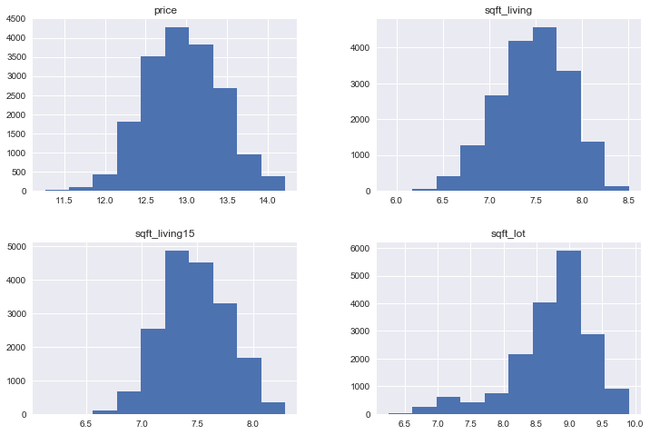

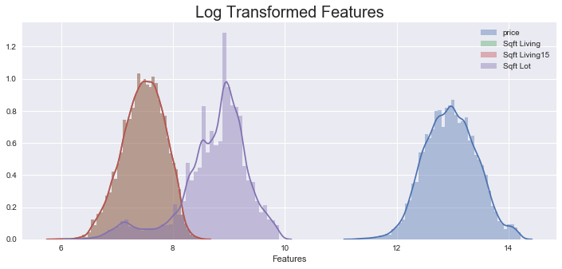

```python
# Perform logarithmic transformation to reduce skewness and decrease variability of data
df_log = pd.DataFrame([])
df_log['price'] = np.log(df['price'])
df_log['sqft_living']  = np.log(df['sqft_living'])
df_log['sqft_living15']  = np.log(df['sqft_living15'])
df_log['sqft_lot']  = np.log(df['sqft_lot'])

#Let's inspect the results of the log transformed features

df_log.hist(figsize  = [12, 8]);

plt.figure(figsize=(12,5))
sns.distplot(df_log.price, label='price')
sns.distplot(df_log.sqft_living, label='Sqft Living')
sns.distplot(df_log.sqft_living, label='Sqft Living15')
sns.distplot(df_log.sqft_lot, label='Sqft Lot')

plt.title('Log Transformed Features', fontdict={'fontsize': 20})
plt.xlabel('Features')
plt.legend()
plt.show()
```

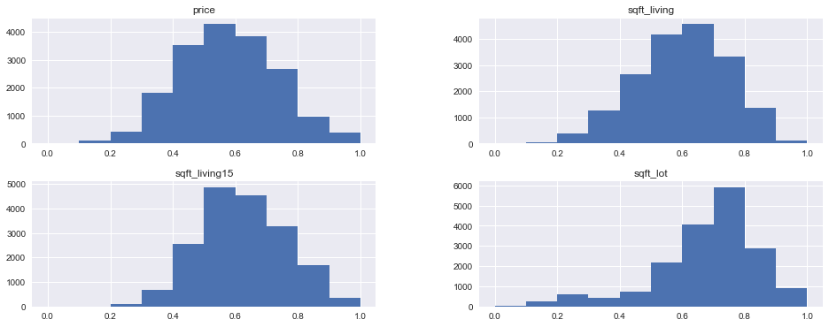

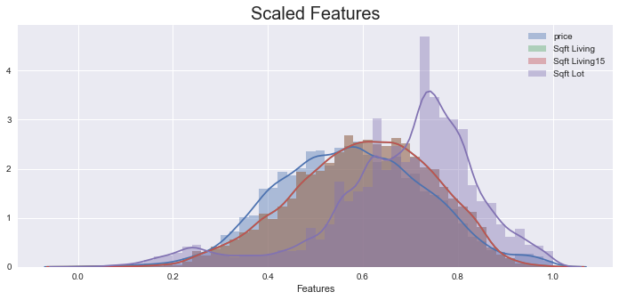

```python
#We can see an improvement on the skewness
logprice = df_log['price']
logsqft_living = df_log['sqft_living']
logsqft_living15 = df_log['sqft_living15']
logsqft_lot = df_log['sqft_lot']

# Let's perform Min Max Scaling to bring the values between 0 and 1 to manage the difference in magnitude

df['price'] = ( logprice - min(logprice) ) / ( max(logprice) - min(logprice) )
df['sqft_living'] = ( logsqft_living - min(logsqft_living) ) / ( max(logsqft_living) - min(logsqft_living) )
df['sqft_living15'] = ( logsqft_living15 - min(logsqft_living15) ) / ( max(logsqft_living15) - min(logsqft_living15) )
df['sqft_lot'] = ( logsqft_lot - min(logsqft_lot) ) / ( max(logsqft_lot) - min(logsqft_lot) )

data_cont_scaled = pd.DataFrame([])
data_cont_scaled['price']= df['price']
data_cont_scaled['sqft_living'] = df['sqft_living']
data_cont_scaled['sqft_living15'] = df['sqft_living15']
data_cont_scaled['sqft_lot']  = df['sqft_lot']

data_cont_scaled.hist(figsize  = [16, 6]);

plt.figure(figsize=(12,5))
sns.distplot(data_cont_scaled.price, label='price')
sns.distplot(data_cont_scaled.sqft_living, label='Sqft Living')
sns.distplot(data_cont_scaled.sqft_living, label='Sqft Living15')
sns.distplot(data_cont_scaled.sqft_lot, label='Sqft Lot')

plt.title('Scaled Features', fontdict={'fontsize': 20})
plt.xlabel('Features')
plt.legend()
plt.show()
```

```python
#Let's re-check skewness
for col in df_log:
    print (col, "Skew is:", df_log[col].skew())
```

```
price Skew is: 0.02072885331482424
sqft_living Skew is: -0.2770491320915994
sqft_living15 Skew is: 0.0716188216502779
sqft_lot Skew is: -1.1015404801588142
```

```python
# Add the dummy variables to the dataset and drop the original variables from the data
df = pd.concat([data_cont_scaled, dumwaterfront, dumview, dumcondition, dumgrade, dumzipcode, dumbedrooms, dumfloors, dumyr_built, dumbathrooms,dumlat,dumlong, dumyr_renovated,dumsqft_basement], axis = 1)
#df.drop(['waterfront','view','condition','grade','zipcode','bedrooms', 'floors', 'yr_built', 'bathrooms'], axis=1, inplace=True)
df.dtypes.to_csv('transformed_datatyp.csv')
df.info()
```

```
<class 'pandas.core.frame.DataFrame'>
Int64Index: 18011 entries, 0 to 21596
Columns: 235 entries, price to basement_1
dtypes: float64(4), uint8(231)
memory usage: 4.7 MB
```

```python
#Before we run the model, let's fix our floor categorical variable
#We are getting some error due to column names of some dummy variables that were created, so we will rename them
df.rename(columns={'floors_1.5':'floors_1_5', 'floors_2.0':'floors_2_0',
                   'floors_2.5':'floors_2_5', 'floors_3.0':'floors_3_0', 'floors_3.5':'floors_3_5'}, inplace=True)
#We could also prevent this by converting the variable to int prior to changing to category data type
```

[Jump back to Table of Contents]

### 4c. Run the Linear Model

```python
# print(df.columns[1:2])     #sqft_living
# print(df.columns[2:3])   #sqft_living15
# print(df.columns[3:4])   #sqft_lot
# print(df.columns[4:5])   #waterfront_1
# print(df.columns[5:9])   #view
# print(df.columns[9:13])   #cond
# print(df.columns[13:21])  #grade
# print(df.columns[21:90])  #zip
# print(df.columns[90:94])  #bedroom
# print(df.columns[94:99])  #floor
# print(df.columns[99:214])  #yrbuilt
# print(df.columns[214:217])  #bathroom
# print(df.columns[217:225])  #lat
# print(df.columns[225:233])  #long
# print(df.columns[233:234])  #renov
# print(df.columns[234:235])  #basement_1'
df.columns.tolist()
```

```
['price',
 'sqft_living',
 'sqft_living15',
 'sqft_lot',
 'waterfront_1',
 'view_1',
 'view_2',
 'view_3',
 'view_4',
 'condition_2',
 'condition_3',
 'condition_4',
 'condition_5',
 'grade_4',
 'grade_5',
 'grade_6',
 'grade_7',
 'grade_8',
 'grade_9',
 'grade_10',
 'grade_11',
 'zipcode_98002',
 'zipcode_98003',
 'zipcode_98004',
 'zipcode_98005',
 'zipcode_98006',
 'zipcode_98007',
 'zipcode_98008',
 'zipcode_98010',
 'zipcode_98011',
 'zipcode_98014',
 'zipcode_98019',
 'zipcode_98022',
 'zipcode_98023',
 'zipcode_98024',
 'zipcode_98027',
 'zipcode_98028',
 'zipcode_98029',
 'zipcode_98030',
 'zipcode_98031',
```

[output cut: 180 more lines]

```
 'lat_5',
 'lat_6',
 'lat_7',
 'lat_8',
 'lat_9',
 'long_2',
 'long_3',
 'long_4',
 'long_5',
 'long_6',
 'long_7',
 'long_8',
 'long_9',
 'renovated_1',
 'basement_1']
```

```python
X = df.drop('price', axis = 1)
y = pd.DataFrame(df, columns = ['price'])

columns = df.describe().columns.drop(['price'])

results = [['variable', 'r_sqr', 'intercept', 'slope', 'p_value']]
for x, val in enumerate(columns):
    print ("price~" + val)
    print ("------------------------------")

    f = 'price~' + val
    model = smf.ols(formula=f, data=df).fit()
    X_new = pd.DataFrame({val: [df[val].min(), df[val].max()]});
    preds = model.predict(X_new)
    results.append([val, model.rsquared, model.params[0], model.params[1], model.pvalues[1]])

    print(results[x + 1])
    print('\n')
```

```
price~sqft_living
------------------------------
['sqft_living', 0.33566915806789244, 0.20284406983899667, 0.6209347082939023, 0.0]


price~sqft_living15
------------------------------
['sqft_living15', 0.2705257907289236, 0.20412249472637456, 0.5961245507941879, 0.0]


price~sqft_lot
------------------------------
['sqft_lot', 0.002292708493446982, 0.6072844768698767, -0.04520377785686064, 1.282095578898449e-10]


price~waterfront_1
------------------------------
['waterfront_1', 0.004748759131559699, 0.5760618971223628, 0.24395844193730135, 2.0712457070960928e-20]


price~view_1
------------------------------
['view_1', 0.009258901246104179, 0.5747274556599109, 0.12625259941095576, 2.5810689134743335e-38]


price~view_2
------------------------------
['view_2', 0.023920046359749314, 0.5717305418724116, 0.12580026871319813, 8.036287495401184e-97]


price~view_3
------------------------------
['view_3', 0.022034092000003058, 0.5735188686340706, 0.18053498860611503, 2.96124364745427e-89]


price~view_4
------------------------------
['view_4', 0.016974189727207545, 0.5748242516910858, 0.24275415220894292, 5.113739610943512e-69]


```

[output cut: 1113 more lines]

```


price~long_9
------------------------------
['long_9', -2.220446049250313e-16, 0.5765359710476199, 0.0, nan]


price~renovated_1
------------------------------
['renovated_1', 0.009285075927695341, 0.5738796946585868, 0.08762306601258878, 2.0317812365654277e-38]


price~basement_1
------------------------------
['basement_1', 0.05428344808196184, 0.5478063241585749, 0.07465728900859663, 1.4004640619467979e-220]
```

```python
#Let's rerun the linear regression model on our log transformed and scaled features
waterfront_1_col = df.columns[4:5]
view_cols = df.columns[5:9]
cond_cols = df.columns[9:13]
grade_cols = df.columns[13:21]
zip_cols = df.columns[21:90]
bed_cols = df.columns[90:94]
flr_cols = df.columns[94:99]
yrbuilt_cols =  df.columns[99:214]
bath_cols =  df.columns[214:217]
lat_cols = df.columns[217:225]
long_cols = df.columns[225:233]
yrrenov_cols =  df.columns[233:234]
sqbase_cols = df.columns[234:235]
cols = [waterfront_1_col, view_cols, cond_cols, grade_cols, zip_cols ,
        bed_cols, flr_cols, yrbuilt_cols,bath_cols , lat_cols, long_cols, yrrenov_cols,sqbase_cols ]
for col in cols:
    sum_cols = '+'.join(col)
    formula = 'price ~' + sum_cols
    model = smf.ols(formula = formula, data = df).fit()
    print(model.summary())
```

```
                            OLS Regression Results
==============================================================================
Dep. Variable:                  price   R-squared:                       0.005
Model:                            OLS   Adj. R-squared:                  0.005
Method:                 Least Squares   F-statistic:                     85.93
Date:                Thu, 18 Apr 2019   Prob (F-statistic):           2.07e-20
Time:                        09:52:44   Log-Likelihood:                 7959.6
No. Observations:               18011   AIC:                        -1.592e+04
Df Residuals:                   18009   BIC:                        -1.590e+04
Df Model:                           1
Covariance Type:            nonrobust
================================================================================
                   coef    std err          t      P>|t|      [0.025      0.975]
--------------------------------------------------------------------------------
Intercept        0.5761      0.001    496.543      0.000       0.574       0.578
waterfront_1     0.2440      0.026      9.270      0.000       0.192       0.296
==============================================================================
Omnibus:                       22.696   Durbin-Watson:                   1.981
Prob(Omnibus):                  0.000   Jarque-Bera (JB):               19.539
Skew:                           0.017   Prob(JB):                     5.72e-05
Kurtosis:                       2.842   Cond. No.                         22.7
==============================================================================

Warnings:
[1] Standard Errors assume that the covariance matrix of the errors is correctly specified.
                            OLS Regression Results
==============================================================================
Dep. Variable:                  price   R-squared:                       0.076
Model:                            OLS   Adj. R-squared:                  0.076
Method:                 Least Squares   F-statistic:                     370.8
Date:                Thu, 18 Apr 2019   Prob (F-statistic):          2.04e-307
Time:                        09:52:44   Log-Likelihood:                 8629.7
No. Observations:               18011   AIC:                        -1.725e+04
Df Residuals:                   18006   BIC:                        -1.721e+04
Df Model:                           4
Covariance Type:            nonrobust
==============================================================================
                 coef    std err          t      P>|t|      [0.025      0.975]
------------------------------------------------------------------------------
Intercept      0.5646      0.001    485.850      0.000       0.562       0.567
```

[output cut: 492 more lines]

```
Covariance Type:            nonrobust
==============================================================================
                 coef    std err          t      P>|t|      [0.025      0.975]
------------------------------------------------------------------------------
Intercept      0.5478      0.001    380.298      0.000       0.545       0.551
basement_1     0.0747      0.002     32.151      0.000       0.070       0.079
==============================================================================
Omnibus:                       37.029   Durbin-Watson:                   1.983
Prob(Omnibus):                  0.000   Jarque-Bera (JB):               31.188
Skew:                           0.037   Prob(JB):                     1.69e-07
Kurtosis:                       2.810   Cond. No.                         2.44
==============================================================================

Warnings:
[1] Standard Errors assume that the covariance matrix of the errors is correctly specified.
```

```python
#Let's view the above result in a dataframe and save to a list to view the results

resultsfin = pd.DataFrame(results)

new_header = resultsfin.iloc[0] #grab the first row for the header
resultsfin = resultsfin[1:] #take the data less the header row
resultsfin.columns = new_header #set the header row as the df header
resultsfin.head(200).to_csv('results1_data.csv')
```

[Jump back to Table of Contents]

### 4d. Model Fit with most appropriate variables

```python
#Let's drop sqft_lot continuous variables which resulted in single linear models with a R-squared value <0.01
df_final = df.drop(['sqft_lot'],
            axis = 1)
#df_final.describe()
```

```python
#Let's create a for loop using RFE where we look at the 217 best features to be selected according to the feature ranking algorithm
y = df_final[['price']]
X = df_final.drop(['price'], axis = 1)

linreg = LinearRegression()

R2_list = [ ]
adj_R2_list= [ ]

for n in list(range(5,218,10)):
    selector = RFE (linreg,n_features_to_select = n)
    selector = selector.fit(X,y)
    selected_columns = X.columns[selector.support_]

    linreg.fit(X[selected_columns],y)

    yhat = linreg.predict(X[selected_columns])
    SSR = np.sum ((y-yhat)**2)
    SST = np.sum ((y-np.mean(y))**2)
    R2 = 1 - (SSR/SST)
    adj_R2 = 1 - (1-R2)*(len(y)-1)/(len(y)-X.shape[1]-1)

    R2_list.append(R2)
    adj_R2_list.append(adj_R2)
    print("{} variables: R2: {}, adj_R2: {}".format(n,round(R2,2),round(adj_R2,2)))
```

```
5 variables: R2: price    0.38
dtype: float64, adj_R2: price    0.37
dtype: float64
15 variables: R2: price    0.54
dtype: float64, adj_R2: price    0.53
dtype: float64
25 variables: R2: price    0.66
dtype: float64, adj_R2: price    0.66
dtype: float64
35 variables: R2: price    0.75
dtype: float64, adj_R2: price    0.74
dtype: float64
45 variables: R2: price    0.8
dtype: float64, adj_R2: price    0.79
dtype: float64
55 variables: R2: price    0.81
dtype: float64, adj_R2: price    0.81
dtype: float64
65 variables: R2: price    0.83
dtype: float64, adj_R2: price    0.83
dtype: float64
75 variables: R2: price    0.85
dtype: float64, adj_R2: price    0.85
dtype: float64
85 variables: R2: price    0.86
dtype: float64, adj_R2: price    0.86
dtype: float64
95 variables: R2: price    0.86
dtype: float64, adj_R2: price    0.86
dtype: float64
105 variables: R2: price    0.86
dtype: float64, adj_R2: price    0.86
dtype: float64
115 variables: R2: price    0.86
dtype: float64, adj_R2: price    0.86
dtype: float64
125 variables: R2: price    0.86
dtype: float64, adj_R2: price    0.86
dtype: float64
135 variables: R2: price    0.86
```

[output cut: 11 more lines]

```
175 variables: R2: price    0.87
dtype: float64, adj_R2: price    0.86
dtype: float64
185 variables: R2: price    0.87
dtype: float64, adj_R2: price    0.86
dtype: float64
195 variables: R2: price    0.87
dtype: float64, adj_R2: price    0.86
dtype: float64
205 variables: R2: price    0.87
dtype: float64, adj_R2: price    0.86
dtype: float64
215 variables: R2: price    0.87
dtype: float64, adj_R2: price    0.86
dtype: float64
```

There is no significant difference between 𝑅2 and adjusted 𝑅2, and seems to continue to be going up as we include more features. It would be likely that we are overfitting when including 217 features. In order to identify this, let's re-run, but using a train test split of 20-80

[Jump back to Table of Contents]

### 4e. Train Test Split

```python
import warnings
warnings.filterwarnings('ignore')
from sklearn.model_selection import train_test_split
from sklearn.metrics import mean_squared_error

train_MSE_list = [ ]
test_MSE_list= [ ]

X_train, X_test, y_train, y_test = train_test_split (X,y,test_size = 0.2)

for n in list(range(5,218,10)):
    selector = RFE (linreg,n_features_to_select = n)
    selector = selector.fit(X_train,y_train)
    selected_columns = X_train.columns[selector.support_]

    linreg.fit(X_train[selected_columns],y_train)

    y_hat_train = linreg.predict(X_train[selected_columns])
    y_hat_test = linreg.predict(X_test[selected_columns])

    train_mse = mean_squared_error (y_train, y_hat_train)
    test_mse = mean_squared_error (y_test, y_hat_test)

    train_MSE_list.append(train_mse)
    test_MSE_list.append(train_mse)

    print('{} variables: Test MSE: {}; Train MSE: {}'.format(n,round(test_mse,2),round(train_mse,2)))
```

```
5 variables: Test MSE: 0.01; Train MSE: 0.02
15 variables: Test MSE: 0.01; Train MSE: 0.01
25 variables: Test MSE: 0.01; Train MSE: 0.01
35 variables: Test MSE: 0.01; Train MSE: 0.01
45 variables: Test MSE: 0.0; Train MSE: 0.0
55 variables: Test MSE: 0.0; Train MSE: 0.0
65 variables: Test MSE: 0.0; Train MSE: 0.0
75 variables: Test MSE: 0.0; Train MSE: 0.0
85 variables: Test MSE: 0.0; Train MSE: 0.0
95 variables: Test MSE: 0.0; Train MSE: 0.0
105 variables: Test MSE: 0.0; Train MSE: 0.0
115 variables: Test MSE: 0.0; Train MSE: 0.0
125 variables: Test MSE: 0.0; Train MSE: 0.0
135 variables: Test MSE: 0.0; Train MSE: 0.0
145 variables: Test MSE: 0.0; Train MSE: 0.0
155 variables: Test MSE: 0.0; Train MSE: 0.0
165 variables: Test MSE: 0.0; Train MSE: 0.0
175 variables: Test MSE: 0.0; Train MSE: 0.0
185 variables: Test MSE: 0.0; Train MSE: 0.0
195 variables: Test MSE: 0.0; Train MSE: 0.0
205 variables: Test MSE: 0.0; Train MSE: 0.0
215 variables: Test MSE: 0.0; Train MSE: 0.0
```

```python
# Using only 155 predictors has almost a negligible decrease the model fit. R-squared is .87
#There is no significant difference between  𝑅2  and adjusted  𝑅2, and seems to continue to be going up as
#we include more features. It is likely that we are overfitting when including 215 features.
#In order to identify this, let's rerun, but using a train test split of 20-80
# Let's scan through the predictors and see what the best number of predictors
# to select for is.

# create a range of n_features_to_select to find value of n with lowest MSE

import warnings
warnings.filterwarnings('ignore')

train_MSE_list = [ ]
test_MSE_list= [ ]

X_train, X_test, y_train, y_test = train_test_split (X,y,test_size = 0.2)

for n in list(range(5,156,10)):
    selector = RFE (linreg,n_features_to_select = n)
    selector = selector.fit(X_train,y_train)
    selected_columns = X_train.columns[selector.support_]

    linreg.fit(X_train[selected_columns],y_train)

    y_hat_train = linreg.predict(X_train[selected_columns])
    y_hat_test = linreg.predict(X_test[selected_columns])

    train_mse = mean_squared_error (y_train, y_hat_train)
    test_mse = mean_squared_error (y_test, y_hat_test)

    train_MSE_list.append(train_mse)
    test_MSE_list.append(train_mse)

    print('{} variables: Test MSE: {}; Train MSE: {}'.format(n,round(test_mse,2),round(train_mse,2)))
```

```
5 variables: Test MSE: 0.01; Train MSE: 0.02
15 variables: Test MSE: 0.01; Train MSE: 0.01
25 variables: Test MSE: 0.01; Train MSE: 0.01
35 variables: Test MSE: 0.01; Train MSE: 0.01
45 variables: Test MSE: 0.0; Train MSE: 0.0
55 variables: Test MSE: 0.0; Train MSE: 0.0
65 variables: Test MSE: 0.0; Train MSE: 0.0
75 variables: Test MSE: 0.0; Train MSE: 0.0
85 variables: Test MSE: 0.0; Train MSE: 0.0
95 variables: Test MSE: 0.0; Train MSE: 0.0
105 variables: Test MSE: 0.0; Train MSE: 0.0
115 variables: Test MSE: 0.0; Train MSE: 0.0
125 variables: Test MSE: 0.0; Train MSE: 0.0
135 variables: Test MSE: 0.0; Train MSE: 0.0
145 variables: Test MSE: 0.0; Train MSE: 0.0
155 variables: Test MSE: 0.0; Train MSE: 0.0
```

The Test MSEs have no significant difference with Train MSEs when we add variables. A bigger model will improve our performance, and the test and train performance have no divergence. Now, let's perform cross-validation on our model with all these predictors.

What we see is that both MSE started with almost the same score and keeps improving when we add variables. The test and train performance don't really diverge. Now, let's perform cross-validation on our model with 150 predictors. Our test error is the same as our train error, this could indicate that our model generalize well to future cases.

Let's test overfitting and underfitting by changing the size of our train test split. By default, scikit learn's built in method allocates 25% of the data to the test set and 75% to the training set. Fitting a model on only 10% of the data is apt to lead to underfitting, while training a model on 99% of the data is apt to lead to overfitting.

It helps to get a small mean absolute error (MAE) to help our model predict the output as MAE tells the average of the our variables residuals. The mean square error (MSE) is just like the MAE, but squares the difference before summing them all instead of using the absolute value. MSE will be bigger than our MAE and are influenced more by outliers in our data.

```python
# create a 75/25 train test split
X_train, X_test, y_train, y_test = train_test_split(X, y, test_size=0.25)

#Fitting the model to the train data
linreg = LinearRegression()
linreg.fit(X_train, y_train)
y_pred = linreg.predict(X_test)

#linreg, y_pred, y_test = linear_regression(X, y)
print(len(X_train), len(X_test), len(y_train), len(y_test))

# Errors
print('R_sqr Score:',round(linreg.score(X, y),2))
print('Mean Absolute Error:', round(metrics.mean_absolute_error(y_test, y_pred),5))
print('Root Mean Squared Error:', round(np.sqrt(metrics.mean_squared_error(y_test, y_pred)),5))
print('\n')
print('Average Predicted Price:', round(y_pred.mean(),4))
print('Average Actual Price:', round(y_test.mean(), 4))
```

```
13508 4503 13508 4503
R_sqr Score: 0.87
Mean Absolute Error: 0.04253
Root Mean Squared Error: 0.05811


Average Predicted Price: 0.5783
Average Actual Price: price    0.5777
dtype: float64
```

[Jump back to Table of Contents]

### 4f. Cross-Validation

```python
# select the best predictors

select_150 = RFE(linreg, n_features_to_select = 150)
select_150 = selector.fit(X, np.ravel(y))
selected_columns = X.columns[selector.support_]

cv_10_results = cross_val_score(linreg, X[selected_columns], y, cv=10, scoring="neg_mean_squared_error")

display(cv_10_results)

print(sum(cv_10_results)/len(cv_10_results))
```

```
array([-3.36649058e-03, -1.79548639e+18, -3.22629588e-03, -3.70538131e-03,
       -3.32305892e-03, -3.55277557e-03, -3.47256545e-03, -3.29486431e-03,
       -3.42604021e-03, -2.72031166e-03])
```

```
-1.7954863924589446e+17
```

```python
cv_5_results = np.mean(cross_val_score(linreg, X, y, cv=5, scoring="neg_mean_squared_error"))
cv_20_results = np.mean(cross_val_score(linreg, X, y, cv=20, scoring="neg_mean_squared_error"))
```

```python
print(cv_5_results)
print(cv_20_results)
```

```
-2.1335281680138664e+16
-3.6230888391073395e+17
```

The cross validation yielded really scores. The model performed poorly on some data.

[Jump back to Table of Contents]

### 4g. Feature ranking

```python
#Let's perform Feature ranking with recursive feature elimination to select the 5 most important features

linreg = LinearRegression()
selector = RFE(linreg, n_features_to_select = 5)
selector = selector.fit(X, y)

#selector.support_ will give us the most important features
selector.support_

selected_columns = X.columns[selector.support_ ]
print(selected_columns)
linreg.fit(X[selected_columns],y)

#.ranking_ will give us the ranking of the selected features
#selector.ranking_
```

```
Index(['sqft_living', 'sqft_living15', 'waterfront_1', 'zipcode_98004',
       'zipcode_98039'],
      dtype='object')
```

```
LinearRegression(copy_X=True, fit_intercept=True, n_jobs=None,
         normalize=False)
```

```python
#The .estimator_ will; give us the parameter estimates (.coef_ and .intercept)
estimators = selector.estimator_


print("Top 5 features Coefficients with Intercept=", round(estimators.intercept_,4))
print(sorted(zip(map(lambda x: round(x,4),estimators.coef_), selected_columns)))
print("")
print("Selected features sorted by their rank:")
print(sorted(zip(map(lambda x: round(x, 4), selector.ranking_), selected_columns)))
```

```
Top 5 features Coefficients with Intercept= 0.1532
[(0.2079, 'zipcode_98004'), (0.2145, 'waterfront_1'), (0.2257, 'sqft_living15'), (0.2643, 'zipcode_98039'), (0.4646, 'sqft_living')]

Selected features sorted by their rank:
[(1, 'sqft_living'), (1, 'sqft_living15'), (1, 'waterfront_1'), (72, 'zipcode_98039'), (73, 'zipcode_98004')]
```

```python
#Let's use the statsmodels.api to run our ols on all our data. Manipulate predictor so it includes constant term
import statsmodels.api as sm
from statsmodels.formula.api import ols
X_int = sm.add_constant(X_train)
model = sm.OLS (y_train,X_int.astype(float)).fit()
model.summary()
```

OLS Regression Results

| Dep. Variable: | price | R-squared: | 0.866 |
| --- | --- | --- | --- |
| Model: | OLS | Adj. R-squared: | 0.864 |
| Method: | Least Squares | F-statistic: | 388.1 |
| Date: | Thu, 18 Apr 2019 | Prob (F-statistic): | 0.00 |
| Time: | 10:18:36 | Log-Likelihood: | 19571. |
| No. Observations: | 13508 | AIC: | -3.870e+04 |
| Df Residuals: | 13285 | BIC: | -3.702e+04 |
| Df Model: | 222 |  |  |
| Covariance Type: | nonrobust |  |  |

|  | coef | std err | t | P>\|t\| | [0.025 | 0.975] |
| --- | --- | --- | --- | --- | --- | --- |
| const | 0.1733 | 0.061 | 2.862 | 0.004 | 0.055 | 0.292 |
| sqft_living | 0.3639 | 0.007 | 49.097 | 0.000 | 0.349 | 0.378 |
| sqft_living15 | 0.1216 | 0.006 | 19.604 | 0.000 | 0.109 | 0.134 |
| waterfront_1 | 0.1976 | 0.014 | 14.523 | 0.000 | 0.171 | 0.224 |
| view_1 | 0.0354 | 0.004 | 8.093 | 0.000 | 0.027 | 0.044 |
| view_2 | 0.0379 | 0.003 | 13.990 | 0.000 | 0.033 | 0.043 |
| view_3 | 0.0683 | 0.004 | 17.257 | 0.000 | 0.061 | 0.076 |
| view_4 | 0.0892 | 0.007 | 12.748 | 0.000 | 0.075 | 0.103 |
| condition_2 | 0.0562 | 0.016 | 3.543 | 0.000 | 0.025 | 0.087 |
| condition_3 | 0.0982 | 0.015 | 6.667 | 0.000 | 0.069 | 0.127 |
| condition_4 | 0.1137 | 0.015 | 7.707 | 0.000 | 0.085 | 0.143 |
| condition_5 | 0.1326 | 0.015 | 8.945 | 0.000 | 0.104 | 0.162 |
| grade_4 | -0.2657 | 0.060 | -4.413 | 0.000 | -0.384 | -0.148 |
| grade_5 | -0.2489 | 0.059 | -4.207 | 0.000 | -0.365 | -0.133 |
| grade_6 | -0.2146 | 0.059 | -3.632 | 0.000 | -0.330 | -0.099 |
| grade_7 | -0.1868 | 0.059 | -3.160 | 0.002 | -0.303 | -0.071 |
| grade_8 | -0.1565 | 0.059 | -2.645 | 0.008 | -0.272 | -0.040 |
| grade_9 | -0.1167 | 0.059 | -1.971 | 0.049 | -0.233 | -0.001 |
| grade_10 | -0.0922 | 0.059 | -1.555 | 0.120 | -0.208 | 0.024 |
| grade_11 | -0.0595 | 0.060 | -0.991 | 0.322 | -0.177 | 0.058 |
| zipcode_98002 | -0.0046 | 0.006 | -0.724 | 0.469 | -0.017 | 0.008 |
| zipcode_98003 | 0.0132 | 0.006 | 2.335 | 0.020 | 0.002 | 0.024 |
| zipcode_98004 | 0.3734 | 0.007 | 56.491 | 0.000 | 0.360 | 0.386 |
| zipcode_98005 | 0.2669 | 0.007 | 35.636 | 0.000 | 0.252 | 0.282 |
| zipcode_98006 | 0.2239 | 0.005 | 41.901 | 0.000 | 0.213 | 0.234 |
| zipcode_98007 | 0.2283 | 0.007 | 31.661 | 0.000 | 0.214 | 0.242 |
| zipcode_98008 | 0.2273 | 0.006 | 39.245 | 0.000 | 0.216 | 0.239 |
| zipcode_98010 | 0.0934 | 0.010 | 9.032 | 0.000 | 0.073 | 0.114 |
| zipcode_98011 | 0.1525 | 0.006 | 24.166 | 0.000 | 0.140 | 0.165 |
| zipcode_98014 | 0.1149 | 0.011 | 9.994 | 0.000 | 0.092 | 0.137 |

[output cut: 204 more lines]

| Omnibus: | 1121.667 | Durbin-Watson: | 2.003 |
| --- | --- | --- | --- |
| Prob(Omnibus): | 0.000 | Jarque-Bera (JB): | 4798.392 |
| Skew: | -0.314 | Prob(JB): | 0.00 |
| Kurtosis: | 5.852 | Cond. No. | 1.18e+16 |

Warnings:  
[1] Standard Errors assume that the covariance matrix of the errors is correctly specified.  
[2] The smallest eigenvalue is 3.59e-28. This might indicate that there are  
strong multicollinearity problems or that the design matrix is singular.

```python
from sklearn.linear_model import LinearRegression
linreg = LinearRegression()
linreg.fit(X, y)
#linreg.coef_, linreg.intercept_
```

```
LinearRegression(copy_X=True, fit_intercept=True, n_jobs=None,
         normalize=False)
```

```python
list2 = list(linreg.coef_)[0]
list1 = list(linreg.intercept_)
list1.extend(list2)
statsm = pd.DataFrame(model.params, columns=['Stats'])
statsm['Sklearn'] = list1
statsm
```

|  | Stats | Sklearn |
| --- | --- | --- |
| const | 1.733133e-01 | 1.525733e-01 |
| sqft_living | 3.639274e-01 | 3.649100e-01 |
| sqft_living15 | 1.216243e-01 | 1.198362e-01 |
| waterfront_1 | 1.976382e-01 | 1.779691e-01 |
| view_1 | 3.537157e-02 | 3.631970e-02 |
| view_2 | 3.790694e-02 | 3.850956e-02 |
| view_3 | 6.826448e-02 | 6.565389e-02 |
| view_4 | 8.916238e-02 | 9.061432e-02 |
| condition_2 | 5.621745e-02 | 7.867441e-02 |
| condition_3 | 9.824907e-02 | 1.173768e-01 |
| condition_4 | 1.136725e-01 | 1.329656e-01 |
| condition_5 | 1.325936e-01 | 1.523579e-01 |
| grade_4 | -2.656585e-01 | -2.184555e-01 |
| grade_5 | -2.489371e-01 | -2.206413e-01 |
| grade_6 | -2.146363e-01 | -1.860914e-01 |
| grade_7 | -1.868172e-01 | -1.562231e-01 |
| grade_8 | -1.564574e-01 | -1.259036e-01 |
| grade_9 | -1.166906e-01 | -8.518169e-02 |
| grade_10 | -9.218237e-02 | -6.182238e-02 |
| grade_11 | -5.949821e-02 | -2.772261e-02 |
| zipcode_98002 | -4.551874e-03 | -2.985955e-03 |
| zipcode_98003 | 1.323047e-02 | 1.274492e-02 |
| zipcode_98004 | 3.733744e-01 | 3.730883e-01 |
| zipcode_98005 | 2.668607e-01 | 2.684455e-01 |
| zipcode_98006 | 2.239370e-01 | 2.262665e-01 |
| zipcode_98007 | 2.282843e-01 | 2.288108e-01 |
| zipcode_98008 | 2.272948e-01 | 2.304685e-01 |
| zipcode_98010 | 9.343577e-02 | 8.541688e-02 |
| zipcode_98011 | 1.524884e-01 | 1.579765e-01 |
| zipcode_98014 | 1.148800e-01 | 1.277674e-01 |
| ... | ... | ... |
| yr_built_2007 | -2.319752e-02 | -3.110002e-02 |
| yr_built_2008 | -1.574727e-02 | -2.406796e-02 |
| yr_built_2009 | -1.296169e-02 | -1.833178e-02 |
| yr_built_2010 | -1.013525e-02 | -1.541423e-02 |
| yr_built_2011 | -7.608467e-03 | -1.240399e-02 |
| yr_built_2012 | -2.438656e-03 | -9.727811e-03 |
| yr_built_2013 | 1.052770e-02 | 3.791001e-03 |
| yr_built_2014 | 9.412850e-03 | 3.718805e-03 |
| yr_built_2015 | -4.060104e-02 | -2.504474e-02 |
| bathrooms_1 | 3.050356e-02 | 9.453087e-03 |
| bathrooms_2 | 3.471470e-02 | 1.383748e-02 |
| bathrooms_3 | 4.440835e-02 | 2.258835e-02 |
| lat_2 | -2.861252e-17 | 2.775558e-17 |
| lat_3 | 3.595513e-20 | -1.040834e-17 |
| lat_4 | -1.273987e-17 | -6.938894e-18 |
| lat_5 | -6.110377e-18 | -4.336809e-18 |
| lat_6 | -1.104228e-17 | 6.938894e-18 |
| lat_7 | 1.233388e-17 | -2.168404e-19 |
| lat_8 | -3.573337e-18 | 6.938894e-18 |
| lat_9 | 0.000000e+00 | 3.469447e-18 |
| long_2 | -3.186522e-02 | -1.497715e-02 |
| long_3 | -5.680772e-02 | -3.290987e-02 |
| long_4 | 0.000000e+00 | 1.610862e-01 |
| long_5 | -1.130339e-01 | -1.087083e-01 |
| long_6 | -1.247739e-01 | -1.612440e-01 |
| long_7 | -5.534883e-02 | -6.412091e-02 |
| long_8 | 0.000000e+00 | 0.000000e+00 |
| long_9 | 0.000000e+00 | 0.000000e+00 |
| renovated_1 | 2.034910e-02 | 2.035140e-02 |
| basement_1 | -1.198723e-02 | -1.249221e-02 |

234 rows × 2 columns

[Jump back to Table of Contents]

```python
#Fit the linear regression model again using the 5 columns selected
selected_columns = X.columns[selector.support_ ]
linreg.fit(X[selected_columns],y)
print('top 5 features', selected_columns )
```

```
top 5 features Index(['sqft_living', 'sqft_living15', 'waterfront_1', 'zipcode_98004',
       'zipcode_98039'],
      dtype='object')
```

```python
print("Top 5 features: ",selected_columns)
print('\n')
```

```
Top 5 features:  Index(['sqft_living', 'sqft_living15', 'waterfront_1', 'zipcode_98004',
       'zipcode_98039'],
      dtype='object')
```

```python
yhat = linreg.predict(X[selected_columns])
```

```python
#Let's calculate the MSE, the average squared difference between the predicted and actual values.
from sklearn.linear_model import LinearRegression
linreg = LinearRegression()
linreg.fit(X_train, y_train)

y_hat_train = linreg.predict(X_train)
y_hat_test = linreg.predict(X_test)

#Look at residuals and MSE
#MSE works by taking the difference between each of the estimated and the real value, squaring them
#and dividing their sum by the number of samples.
train_residuals = y_hat_train - y_train
test_residuals = y_hat_test - y_test

mse_train = np.sum((y_train-y_hat_train)**2)/len(y_train)
mse_test =np.sum((y_test-y_hat_test)**2)/len(y_test)
print('Train Mean Squarred Error:', mse_train)
print('Test Mean Squarred Error:', mse_test)
```

```
Train Mean Squarred Error: price    0.003229
dtype: float64
Test Mean Squarred Error: price    0.003377
dtype: float64
```

```python
SS_Residual = np.sum((y-yhat)**2)
SS_Total = np.sum((y-np.mean(y))**2)
r_squared = 1 - (float(SS_Residual))/SS_Total
adjusted_r_squared = 1 - (1-r_squared)*(len(y)-1)/(len(y)-X[selected_columns].shape[1]-1)
display(r_squared, adjusted_r_squared)

train_mse = mean_squared_error(y_train, y_hat_train)
test_mse = mean_squared_error(y_test, y_hat_test)
print('Train Mean Squarred Error:', train_mse)
print('Test Mean Squarred Error:', test_mse)
```

```
price    0.382335
dtype: float64
```

```
price    0.382164
dtype: float64
```

```
Train Mean Squarred Error: 0.003228875212972426
Test Mean Squarred Error: 0.003377036903577397
```

[Jump back to Table of Contents]

## 5. iNterpreting the Data

MSE is the loss function, which in this case is low and gives intuition of the best fit estimate.  
The lesser the MSE the smaller is the error and we can say that we have a good estimator because it implies agreement between the prediction and the reality.  
Our estimator performed well in guessing the real values of the prices.  
There does not seem to be a big difference between the train and test MSE. MSE’s value is in helping us to select one prediction model over another.

In this regression project, we try to measure the model parameters (coefficients ) so our null and alternative hypotheses can be accepted or rejected.

NULL HYPOTHESIS (Ho): There is no relationship between Home Sale price and location(zip), sqft living, waterfront, views, condition, etc..

ALTERNATIVE HYPOTHESIS (Ha): There is "some" relation between Home Sale Price and and location(zip), sqft living, waterfront, views, condition, etc.

Rejecting the null hypothesis would help us associate some significance with our results As per out model results, we reject the null (and thus believe the alternative) if the 95% confidence interval does not include zero for co-efficient. The p-value represents the probability that the coefficient is actually zero.

A low R-squared value means that the predictors in oour model do not describe the variation in our dependent variable. This project demonstrated that there are strong relationships between locations (zip/waterfront) and sq ft living area.

R-squared or coefficient of determination is a statistical measure that is used to assess the goodness of fit of a regression model.

R-squared uses a baseline model which is the **worst** model because it does not make use of any independent variables to predict the value of dependent variable Y, but rather it uses the **mean** of the observed responses of dependent variable Y and always predicts this mean as the value of Y. We looked at the adjusted R squared to keep our model in check as this modified R squared will increase only if the new terms improves our model. In this case, the p-value for sqft living is less than 0.05, and so we believe that there is a strong relationship between sqft living and and Home Sale price.

We haven't learn about interpreting AIC or BIC in Module 1 but this model has negative values on the AIC & BIC. According to this forum (https://www.reddit.com/r/AskStatistics/comments/5ydt2c/if_my_aic_and_bic_are_negative_does_that_mean/) Negative AIC indicates less information loss than a positive AIC and therefore a better model from the set of plausible models being considered( the smallest AIC value the least information loss relative to the true model).

```python
#Top Zip codes
dft = pd.read_csv('kc_house_data.csv')
df_topzip  = dft[(dft.zipcode == 98004) | (dft.zipcode == 98039) ]
```

```python
map2 = folium.Map([47.6208,-122.219],tiles='Stamen Toner',  zoom_start = 12)
markers = []

for row in df_topzip.itertuples():
    i = row.Index
    marker = folium.Marker([df_topzip['lat'][i], df_topzip['long'][i]],icon = folium.Icon(color='green'))
    markers.append(marker)
```

```python
for marker in markers:
    #print(marker)
    marker.add_to(map2)
figsize = (20, 18)
map2
```

[interactive chart not shown]

[Jump back to Table of Contents]